# Segmentace průmyslu – data a výpočty po slajdech

Fakta o klimatu · slajd → data → kód → výsledek

Notebook jde po slajdech prezentace *Průmysl – Slidedeck v1* („S“ = číslo snímku). U každého slajdu je **obrázek slajdu**, **data** (zdroj s odkazem), **kód** a **výsledek**, ze kterého se slajd kreslí. Kde to jde, notebook spočítá výsledek znovu přímo ze surových dat a porovná ho s výstupem skriptu (sloupec `shoda`). U slajdů, ke kterým data ještě nejsou, je napsáno, co chybí.

Kód je u každé tabulky sbalený – rozklikněte **Kód**. Před vyrenderováním spusťte `R/run_all.R` (stáhne data a vytvoří `out/`).

## Slovníček pojmů

| Pojem | Co znamená | Kde se používá |
| --- | --- | --- |
| **HPH** – hrubá přidaná hodnota | Hodnota, kterou obor vytvoří: tržby za produkci minus nakoupené vstupy (materiál, energie, služby). Z HPH se platí mzdy, odpisy a zisk. Součet HPH všech oborů ≈ HDP. | S6, S7, S12, D2 |
| **Produkce** (P.1) | Celková hodnota vyrobeného zboží a služeb, vč. vstupů nakoupených od jiných. Vždy větší než HPH. | D1, D3 |
| **Mezispotřeba** | Nakoupené vstupy spotřebované ve výrobě (materiál, díly, energie, služby). Produkce = mezispotřeba + HPH. | S11 |
| **Náhrady zaměstnancům** (D.1 = D.11 + D.12) | Mzdy a platy + sociální a zdravotní pojištění placené zaměstnavatelem. | S11, S19 |
| **Index objemu výroby** | Jak se mění *množství* vyrobeného (očištěno o ceny a o počet pracovních dní). 2015 = 100; hodnota 148 = o 48 % víc než v roce 2015. | S9, S19, S22 |
| **Pracující / zaměstnanci** | Pracující = zaměstnanci + podnikatelé (OSVČ); počet osob v tisících. | S6, S19 |
| **Běžné / kupní / základní ceny** | Běžné = ceny daného roku (bez očištění o inflaci). Kupní = vč. obchodní marže, dopravy a daní z produktů; základní = bez nich. | S11, D1 |
| **PEFA** | Fyzické účty energetických toků: kolik energie (TJ) jednotlivé obory spotřebují a jakých paliv. 1 TJ ≈ 278 MWh. | S12, S13, S25, D2 |
| **SUT** – tabulky dodávek a užití | Tabulka národních účtů ČSÚ: který obor nakupuje jaké výrobky (CZ-CPA) a kolik platí za práci. | S11, S17 |
| **CZ-NACE / CZ-CPA** | Klasifikace oborů (kdo vyrábí) / výrobků (co se vyrábí). Např. obor C24 = hutě, výrobek CPA 35 = elektřina, plyn, pára. | všude |
| **FIGARO** | Mezinárodní input-output tabulka Eurostatu: toky výrobků mezi obory a zeměmi (kdo komu co prodá, vč. vývozu a dovozu). | D1, D3 |
| **Dovozní penetrace** | Podíl dovozu na domácí spotřebě výrobků oboru: dovoz / (produkce − vývoz + dovoz). | D1, D2 |
| **EU ETS, povolenka** | Systém obchodování s emisemi: za každou tunu CO₂ musí podnik odevzdat povolenku. Část povolenek dostává průmysl zdarma. | S15, S17 |
| **Ověřené emise** | Emise zařízení za rok ověřené auditorem a zapsané v registru EU (Union Registry). | S15, S16, S21 |
| **Přímý / nepřímý náklad ETS** | Přímý = povolenky, které podnik musí dokoupit (emise − povolenky zdarma). Nepřímý = povolenky promítnuté do ceny elektřiny. | S17 |
| **SBS** – podniková statistika | Data z výkazů podniků: tržby, nákupy, osobní náklady. Jiný zdroj než národní účty. | váhy indexu výroby (S9) |

**Kód**

```r
library(dplyr); library(tidyr); library(readr); library(readxl)

ROOT <- ".."                                   # kořen projektu (složka se skripty R/)
OUT  <- file.path(ROOT, "out")                 # výstupy skriptů
ES   <- file.path(ROOT, "data/eurostat")       # stažená data Eurostatu
MAN  <- file.path(ROOT, "data/manual")         # ruční převodníky

es  <- function(name) read_csv(file.path(ES, paste0(name, ".csv")), show_col_types = FALSE)
out <- function(name) read_csv(file.path(OUT, paste0(name, ".csv")), show_col_types = FALSE)
num <- function(x) suppressWarnings(as.numeric(x))   # "n/a", "Excluded" -> NA

# shoda vlastního přepočtu s výstupem skriptu
shoda <- function(a, b) isTRUE(all.equal(a, b, tolerance = 1e-9))

EUA_2024 <- 65.01   # €/t, průměrná cena aukcí 2024, DEHSt (R/00_setup.R)
EF_ELEC  <- 0.85    # t CO2/MWh, max. regionální faktor CZ-SK, pokyny ke státní podpoře v ETS

# Společná data, která používá víc slajdů
inst <- out("registry_installations")            # zařízení EU ETS × rok, s oborem (R/02_registry.R)
i25  <- inst |> filter(year == 2025)
idx  <- out("production_index_annual") |>        # index výroby 2015 = 100 (R/08_production_annual.R)
  filter(time == 2025) |> transmute(geo, nace, zmena_pct = index_2015 - 100) |>
  pivot_wider(names_from = geo, values_from = zmena_pct)
ets  <- out("ets_costs_2024")                    # náklady ETS 2024 (R/03_ets_costs.R)

# podíl povolenek zdarma na ověřených emisích
podil_zdarma <- function(d) d |>
  summarise(zarizeni = n(), zdarma_kt = sum(free_alloc, na.rm = TRUE) / 1e3,
            emise_kt = sum(verified_em, na.rm = TRUE) / 1e3) |>
  mutate(podil_pct = zdarma_kt / emise_kt * 100)
```

# S3 – Krátká odpověď: čtyři zjištění

[figure not shown]

**PoznámkaCo jsou to za data**

*souhrn čísel ze S9, S11, S15 a S17*

Čísla pro snímek, spočítaná z výstupů skriptů:

**Kód**

```r
sut_s3 <- out("naklady_sut"); ets_s3 <- out("ets_costs_2024")
tibble(
  cesko_rychleji_oboru = sum(idx$CZ > idx$DE, na.rm = TRUE),
  oboru_celkem = sum(!is.na(idx$CZ) & !is.na(idx$DE)),
  energie_pod_5pct_oboru = sum(sut_s3$energie_pct[sut_s3$nace != "C"] < 5),
  energie_nad_10pct = paste(sut_s3$name[sut_s3$nace != "C" & sut_s3$energie_pct > 10], collapse = ", "),
  ets_prumysl_pct_nakladu = round(ets_s3$indirect_net_pct_naklady[ets_s3$nace == "C"] + ets_s3$direct_pct_naklady[ets_s3$nace == "C"], 2),
  zdarma_pct = round(sum(i25$free_alloc, na.rm = TRUE) / sum(i25$verified_em, na.rm = TRUE) * 100))
```

| cesko_rychleji_oboru | oboru_celkem | energie_pod_5pct_oboru | energie_nad_10pct | ets_prumysl_pct_nakladu | zdarma_pct |
| --- | --- | --- | --- | --- | --- |
| 16 | 18 | 13 | Hutě a slévárny, Chemie, Cement, sklo, keramika | 0.55 | 72 |

*Pozn.:* Náklady na povolenky = nepřímé (elektřina ze sítě po kompenzaci, horní odhad) + přímé netto, v % celkových nákladů průmyslu ze SUT ČSÚ.

# S5 – Jak se českému průmyslu daří? (průmysl v číslech)

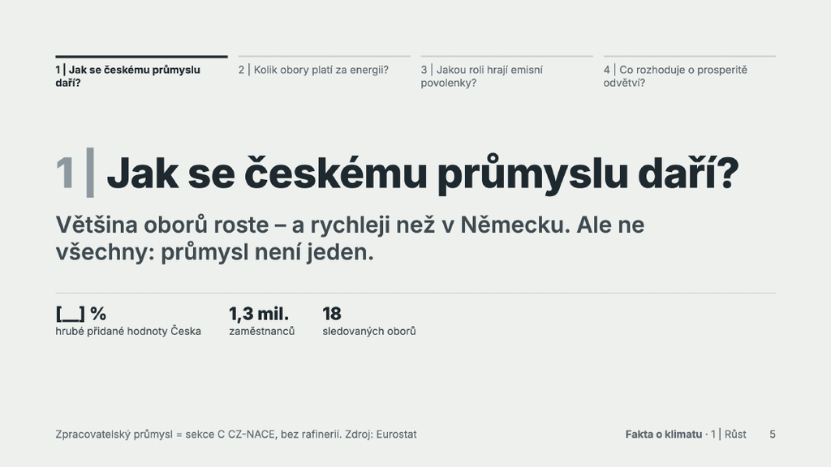

**PoznámkaCo jsou to za data**

*Eurostat národní účty · 2025 (předběžně)*

- **Podíl na HPH Česka** = HPH 18 oborů zpracovatelského průmyslu (bez rafinerií) / HPH celé ekonomiky.
- **Pracující** = zaměstnanci + podnikatelé; **zaměstnanci** jen v pracovním poměru.

**Data:** Eurostat [`nama_10_a64`](https://ec.europa.eu/eurostat/databrowser/view/nama_10_a64/default/table) (`B1G`, `TOTAL` a obory C), [`nama_10_a64_e`](https://ec.europa.eu/eurostat/databrowser/view/nama_10_a64_e/default/table). Skript: `R/11_hph_zamestnanost.R`.

**Kód**

```r
out("prumysl_kpi_2025") |> mutate(across(where(is.double), \(x) round(x, 1)))
```

| rok | podil_hph_cr_pct | pracujici_tis | zamestnanci_tis | oboru |
| --- | --- | --- | --- | --- |
| 2025 | 20.8 | 1325 | 1215.4 | 18 |

# S6 – Český průmysl je pestrá mozaika

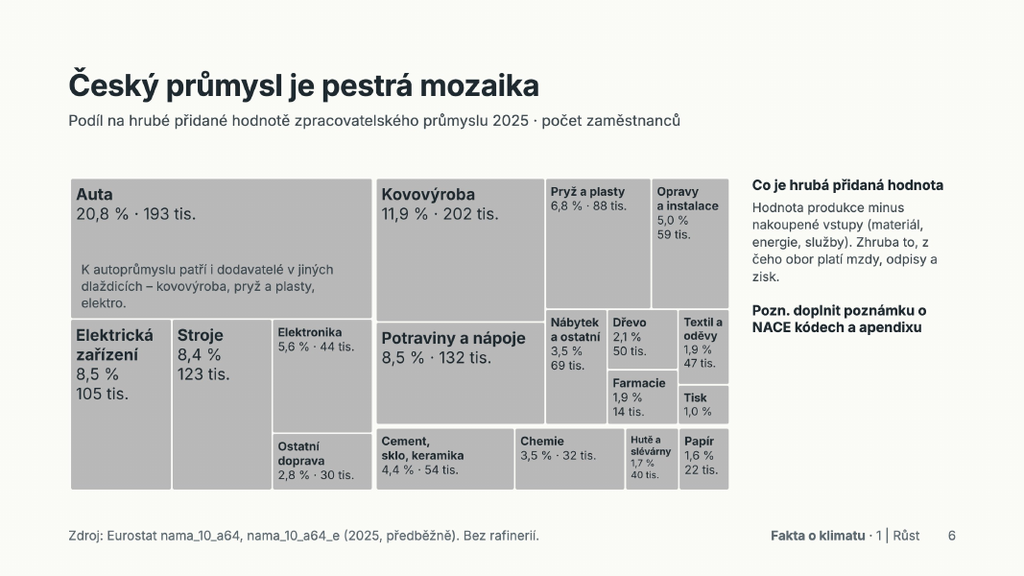

**PoznámkaCo jsou to za data**

*ČSÚ/Eurostat národní účty · 2025 (předběžně) · mil. € a tis. osob*

- **HPH** oboru = kolik hodnoty obor sám vytvoří (tržby za produkci minus nakoupené vstupy). Ukazuje skutečnou „velikost“ oboru v ekonomice lépe než tržby, které obsahují i nakoupené díly.
- **Podíl** = HPH oboru / HPH zpracovatelského průmyslu bez rafinerií.
- **Pracující** = zaměstnanci + podnikatelé v oboru, tisíce osob.

**Na slajdu:** podíl oboru na HPH zpracovatelského průmyslu 2025 (bez rafinerií) a počet pracujících.

**Data:** Eurostat [`nama_10_a64`](https://ec.europa.eu/eurostat/databrowser/view/nama_10_a64/default/table) (HPH `B1G`, běžné ceny, mil. €) a [`nama_10_a64_e`](https://ec.europa.eu/eurostat/databrowser/view/nama_10_a64_e/default/table) (pracující `EMP_DC`, tis. osob), ČR 2025 (předběžně). Skript: `R/11_hph_zamestnanost.R`.

Podíl = HPH oboru / součet HPH 18 oborů (bez C19). Notebook ho počítá přímo ze stažených dat Eurostatu:

**Kód**

```r
nama <- es("nama_10_a64_CZ") |> filter(na_item == "B1G", time == 2025)
c_celk <- nama$values[nama$nace_r2 == "C"]; c19 <- nama$values[nama$nace_r2 == "C19"]
tibble(C_celkem = c_celk, C19 = c19, C_bez_C19 = c_celk - c19)   # jmenovatel
```

| C_celkem | C19 | C_bez_C19 |
| --- | --- | --- |
| 65987.6 | 50.6 | 65937 |

**Kód**

```r
vel <- out("obory_velikost_2025")
z_es <- nama |> filter(!nace_r2 %in% c("TOTAL", "C", "C19")) |>
  transmute(nace = recode(nace_r2, "C10-C12" = "C10-12", "C13-C15" = "C13-15", "C31_C32" = "C31_32"),
            podil_es = values / sum(values) * 100)
vel |> left_join(z_es, by = "nace") |>
  mutate(shoda = mapply(shoda, podil_hph_pct, podil_es)) |>
  transmute(nace, obor = name, hph_meur, podil_hph_pct = round(podil_hph_pct, 1),
            pracujici_tis = round(pracujici_tis), shoda)
```

| nace | obor | hph_meur | podil_hph_pct | pracujici_tis | shoda |
| --- | --- | --- | --- | --- | --- |
| C29 | Auta | 13750.2 | 20.9 | 193 | TRUE |
| C25 | Kovovýroba | 7836.1 | 11.9 | 202 | TRUE |
| C10-12 | Potraviny a nápoje | 5594.4 | 8.5 | 132 | TRUE |
| C27 | Elektrická zařízení | 5593.9 | 8.5 | 105 | TRUE |
| C28 | Stroje | 5536.8 | 8.4 | 123 | TRUE |
| C22 | Pryž a plasty | 4454.8 | 6.8 | 88 | TRUE |
| C26 | Elektronika | 3699.1 | 5.6 | 44 | TRUE |
| C33 | Opravy a instalace | 3283.7 | 5.0 | 59 | TRUE |
| C23 | Cement, sklo, keramika | 2885.8 | 4.4 | 54 | TRUE |
| C20 | Chemie | 2340.9 | 3.6 | 32 | TRUE |
| C31_32 | Nábytek a ostatní | 2317.5 | 3.5 | 69 | TRUE |
| C30 | Ostatní doprava | 1817.6 | 2.8 | 30 | TRUE |
| C16 | Dřevo | 1411.9 | 2.1 | 50 | TRUE |
| C21 | Farmacie | 1265.4 | 1.9 | 14 | TRUE |
| C13-15 | Textil a oděvy | 1264.3 | 1.9 | 47 | TRUE |
| C24 | Hutě a slévárny | 1117.6 | 1.7 | 40 | TRUE |
| C17 | Papír | 1086.8 | 1.6 | 22 | TRUE |
| C18 | Tisk | 680.2 | 1.0 | 21 | TRUE |

# S7 – Jak se v tom vyznat? Dvě skupiny oborů

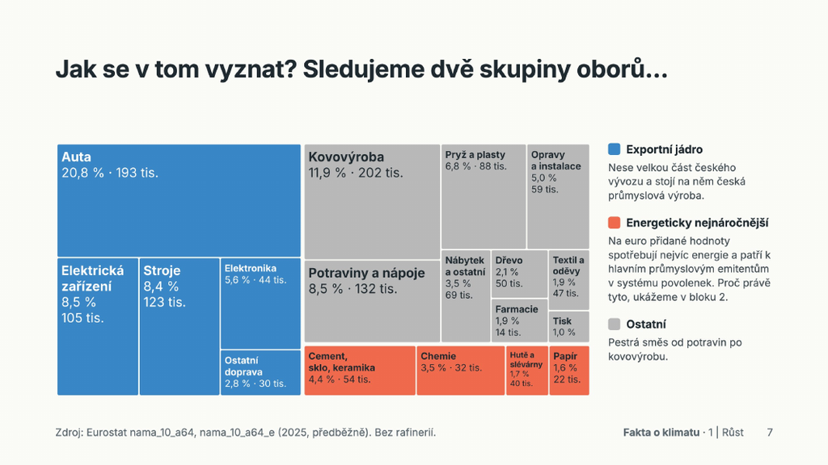

**PoznámkaCo jsou to za data**

*stejná data jako S6*

- Obory jsou rozdělené do dvou sledovaných skupin. **Exportní jádro** (auta, stroje, elektro, elektronika, ostatní doprava) nese většinu vývozu.
- **Energeticky nejnáročnější** (hutě, chemie, cement/sklo/keramika, papír) spotřebují nejvíc energie na euro HPH (S12) a jsou hlavními emitenty v EU ETS.

**Data:** jako S6. Skupiny jsou definované v `R/00_setup.R`: exportní jádro = C26–C30, energeticky nejnáročnější = C17, C20, C23, C24 (podle S12 a registru ETS).

**Kód**

```r
vel |> group_by(skupina) |>
  summarise(obory = paste(nace, collapse = ", "), podil_hph_pct = round(sum(podil_hph_pct), 1),
            pracujici_tis = round(sum(pracujici_tis)))
```

| skupina | obory | podil_hph_pct | pracujici_tis |
| --- | --- | --- | --- |
| energeticky nejnáročnější | C23, C20, C24, C17 | 11.3 | 149 |
| exportní jádro | C29, C27, C28, C26, C30 | 46.1 | 495 |
| ostatní | C25, C10-12, C22, C33, C31_32, C16, C21, C13-15, C18 | 42.6 | 681 |

**Kontrola: sedí „exportní jádro“?** Rozklad českého vývozu zpracovatelského průmyslu podle oborů, Eurostat FIGARO 2024 (`R/14_figaro.R`; vývoz = dodávky z ČR do zahraničí, mil. €, základní ceny). Exportní jádro by mělo mít velký podíl na vývozu *a* vysoký podíl vývozu na vlastní produkci.

**Kód**

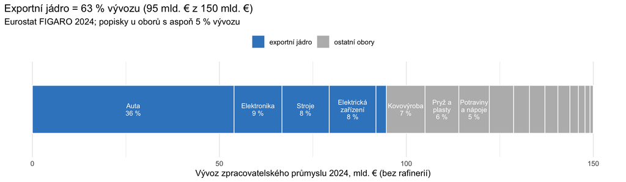

```r
library(ggplot2)
BARVY <- c("exportní jádro" = "#3a87c8", "energeticky nejnáročnější" = "#f06a4e", "ostatní" = "#b9b9b9")
vyvoz <- out("figaro_obory") |> filter(rok == 2024, nace != "C19") |>
  mutate(skupina = case_when(nace %in% c("C26", "C27", "C28", "C29", "C30") ~ "exportní jádro",
                             nace %in% c("C17", "C20", "C23", "C24") ~ "energeticky nejnáročnější",
                             TRUE ~ "ostatní"),
         podil_na_vyvozu_pct = E / sum(E) * 100,     # podíl oboru na vývozu průmyslu (bez rafinerií)
         vyvoz_z_produkce_pct = E / P * 100)         # kolik z produkce oboru jde do zahraničí

# jeden pruh = celý vývoz zpracovatelského průmyslu; díly = obory (jádro vlevo, pak ostatní, od největšího)
vyvoz <- vyvoz |>
  mutate(jadro = if_else(skupina == "exportní jádro", "exportní jádro", "ostatní obory")) |>
  arrange(jadro, desc(E)) |>
  mutate(name = factor(name, levels = rev(name)),
         popisek = if_else(podil_na_vyvozu_pct >= 5, sprintf("%s\n%.0f %%", stringr::str_wrap(name, 10), podil_na_vyvozu_pct), ""))
celkem <- vyvoz |> group_by(jadro) |> summarise(mld = sum(E) / 1000, pct = sum(podil_na_vyvozu_pct))

ggplot(vyvoz, aes(x = E / 1000, y = "vývoz", fill = jadro, group = name)) +
  geom_col(colour = "white", linewidth = .4, width = .6) +
  geom_text(aes(label = popisek), position = position_stack(vjust = .5), size = 3, colour = "white", lineheight = .9) +
  scale_fill_manual(values = c("exportní jádro" = "#3a87c8", "ostatní obory" = "#b9b9b9"), name = NULL) +
  labs(x = "Vývoz zpracovatelského průmyslu 2024, mld. € (bez rafinerií)", y = NULL,
       title = sprintf("Exportní jádro = %.0f %% vývozu (%.0f mld. € z %.0f mld. €)",
                       celkem$pct[celkem$jadro == "exportní jádro"], celkem$mld[celkem$jadro == "exportní jádro"], sum(celkem$mld)),
       subtitle = "Eurostat FIGARO 2024; popisky u oborů s aspoň 5 % vývozu") +
  theme_minimal(base_size = 11) +
  theme(legend.position = "top", axis.text.y = element_blank(), panel.grid.major.y = element_blank())
```

Souhrn za skupiny:

**Kód**

```r
vyvoz |> group_by(skupina) |>
  summarise(obory = paste(nace, collapse = ", "), vyvoz_mld_eur = round(sum(E) / 1000, 1),
            podil_na_vyvozu_pct = round(sum(podil_na_vyvozu_pct), 1),
            vyvoz_z_produkce_pct = round(sum(E) / sum(P) * 100))
```

| skupina | obory | vyvoz_mld_eur | podil_na_vyvozu_pct | vyvoz_z_produkce_pct |
| --- | --- | --- | --- | --- |
| energeticky nejnáročnější | C20, C24, C23, C17 | 17.3 | 11.5 | 49 |
| exportní jádro | C29, C26, C28, C27, C30 | 94.7 | 63.1 | 74 |
| ostatní | C25, C22, C10-12, C31_32, C13-15, C16, C33, C21, C18 | 38.1 | 25.4 | 48 |

# S8 – Většina oborů průmyslu roste

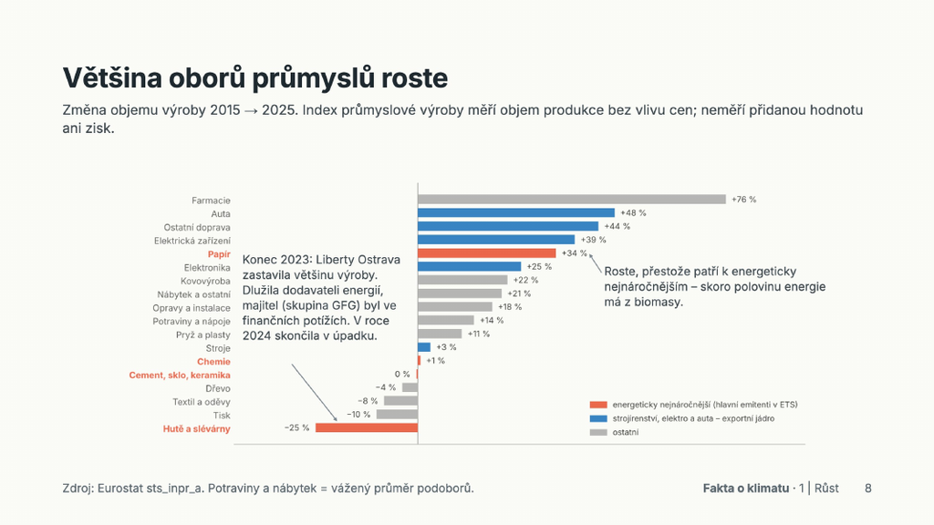

**PoznámkaCo jsou to za data**

*Eurostat krátkodobá statistika · 2015 → 2025*

- Změna **objemu výroby** v Česku 2015 → 2025 (index 2025 / 2015 − 1). Měří množství produkce bez vlivu cen; neměří přidanou hodnotu ani zisk.
- Stejná data jako S9, jen Česko.

**Kód**

```r
idx |> transmute(nace, zmena_CZ_pct = round(CZ)) |>
  left_join(out("obory_velikost_2025") |> select(nace, obor = name, skupina), by = "nace") |>
  arrange(desc(zmena_CZ_pct))
```

| nace | zmena_CZ_pct | obor | skupina |
| --- | --- | --- | --- |
| C21 | 76 | Farmacie | ostatní |
| C29 | 48 | Auta | exportní jádro |
| C30 | 44 | Ostatní doprava | exportní jádro |
| C27 | 39 | Elektrická zařízení | exportní jádro |
| C17 | 34 | Papír | energeticky nejnáročnější |
| C26 | 25 | Elektronika | exportní jádro |
| C25 | 22 | Kovovýroba | ostatní |
| C31_32 | 21 | Nábytek a ostatní | ostatní |
| C33 | 18 | Opravy a instalace | ostatní |
| C10-12 | 14 | Potraviny a nápoje | ostatní |
| C22 | 11 | Pryž a plasty | ostatní |
| C28 | 3 | Stroje | exportní jádro |
| C20 | 1 | Chemie | energeticky nejnáročnější |
| C23 | 0 | Cement, sklo, keramika | energeticky nejnáročnější |
| C16 | -4 | Dřevo | ostatní |
| C13-15 | -8 | Textil a oděvy | ostatní |
| C18 | -10 | Tisk | ostatní |
| C24 | -25 | Hutě a slévárny | energeticky nejnáročnější |

# S9 – Česko roste rychleji než Německo

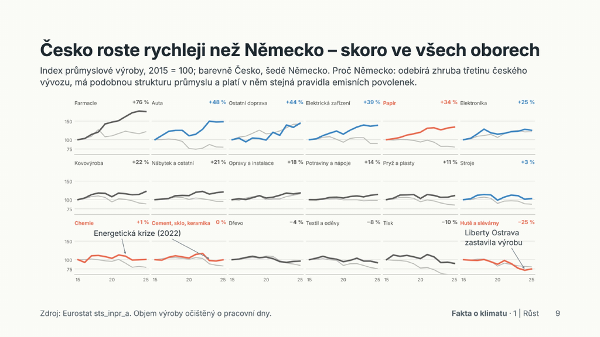

**PoznámkaCo jsou to za data**

*Eurostat krátkodobá statistika · 2015–2025 · index*

- **Index objemu výroby** sleduje *množství* vyrobeného, ne tržby: je očištěný o změny cen a o počet pracovních dní. Proto se dají porovnat roky i země.
- Změna 2015 → 2025: +48 % = obor vyrábí o polovinu víc než před deseti lety.
- Sloučené obory (potraviny C10-12, textil C13-15, nábytek C31_32) se skládají z dílčích indexů vážených přidanou hodnotou.

**Data:** Eurostat [`sts_inpr_a`](https://ec.europa.eu/eurostat/databrowser/view/sts_inpr_a/default/table) – objem výroby, očištěno o pracovní dny, 2021 = 100, přepočteno na 2015 = 100. Sloučené obory (C10-12, C13-15, C31_32) složeny ze složek vážených přidanou hodnotou 2021 ([`sbs_ovw_act`](https://ec.europa.eu/eurostat/databrowser/view/sbs_ovw_act/default/table)). Skript: `R/08_production_annual.R`.

Vstup, např. auta (C29):

**Kód**

```r
sts <- es("sts_inpr_a_annual")
sts |> filter(nace_r2 == "C29", time %in% c(2015, 2025)) |> select(geo, nace_r2, time, values)
```

| geo | nace_r2 | time | values |
| --- | --- | --- | --- |
| CZ | C29 | 2015 | 86.8 |
| CZ | C29 | 2025 | 128.7 |
| DE | C29 | 2015 | 133.5 |
| DE | C29 | 2025 | 106.6 |

Změna 2015 → 2025 = index 2025 / index 2015 − 1. U nesloučených oborů ji notebook počítá přímo z Eurostatu a porovná s výstupem skriptu:

**Kód**

```r
z_es <- sts |> filter(time %in% c(2015, 2025)) |>
  select(geo, nace = nace_r2, time, values) |>
  pivot_wider(names_from = time, values_from = values) |>
  mutate(zmena = (`2025` / `2015` - 1) * 100) |> select(geo, nace, zmena) |>
  pivot_wider(names_from = geo, values_from = zmena, names_prefix = "es_")

idx |> left_join(z_es, by = "nace") |>
  mutate(CZ_rychleji = CZ > DE,
         shoda = if_else(is.na(es_CZ), NA, mapply(shoda, CZ, es_CZ) & mapply(shoda, DE, es_DE))) |>
  transmute(nace, CZ_pct = round(CZ, 1), DE_pct = round(DE, 1), CZ_rychleji, shoda) |>
  arrange(desc(CZ_pct))
```

| nace | CZ_pct | DE_pct | CZ_rychleji | shoda |
| --- | --- | --- | --- | --- |
| C21 | 75.5 | 21.3 | TRUE | TRUE |
| C29 | 48.3 | -20.1 | TRUE | TRUE |
| C30 | 44.3 | 48.1 | FALSE | TRUE |
| C27 | 38.5 | -10.5 | TRUE | TRUE |
| C17 | 33.9 | -19.9 | TRUE | TRUE |
| C26 | 25.3 | 21.5 | TRUE | TRUE |
| C25 | 22.0 | -11.1 | TRUE | TRUE |
| C31_32 | 20.7 | -4.1 | TRUE | NA |
| C33 | 18.3 | 15.8 | TRUE | TRUE |
| C10-12 | 13.9 | -3.0 | TRUE | NA |
| C22 | 10.8 | -14.4 | TRUE | TRUE |
| C28 | 3.1 | -12.3 | TRUE | TRUE |
| C20 | 0.7 | -20.5 | TRUE | TRUE |
| C23 | -0.3 | -16.8 | TRUE | TRUE |
| C16 | -3.8 | -15.3 | TRUE | TRUE |
| C13-15 | -8.2 | -24.3 | TRUE | NA |
| C18 | -10.1 | -42.8 | TRUE | TRUE |
| C24 | -25.0 | -19.5 | FALSE | TRUE |

**Kód**

```r
sum(idx$CZ > idx$DE, na.rm = TRUE)   # v kolika oborech roste Česko rychleji
```

```
[1] 16
```

`shoda = NA` = sloučený obor, skládá ho `sts_composite()` v `R/funkce.R`.

# S11 – Energie a mzdy: podíl na celkových nákladech

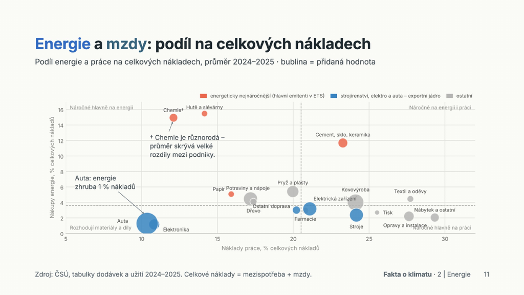

**PoznámkaCo jsou to za data**

*ČSÚ tabulky dodávek a užití · součet 2024 + 2025 · mil. Kč*

- **Celkové náklady** = mezispotřeba (vše nakoupené) + náhrady zaměstnancům (mzdy + odvody).
- **Nákupy energie** = uhlí, ropa a plyn, koks a ropné produkty, elektřina, plyn a teplo ze sítě (výrobky CZ-CPA 05, 06, 19, 35).
- Čísla jsou v **kupních cenách**, tedy vč. obchodních marží, dopravy a spotřebních daní – tak, jak je podnik skutečně platí.
- **Chemie** obsahuje v národních účtech i rafinerii Litvínov; ropa jako surovina se proto nepočítá ani do energie, ani do nákladů.

**Na slajdu:** nákupy energie (osa y) a náklady práce (osa x) v % celkových nákladů, průměr 2024–2025; velikost bubliny = HPH; čáry = medián oborů.

**Data:** ČSÚ, [tabulky dodávek a užití](https://apl.czso.cz/pll/rocenka/rocenkaout.dod_uziti?mylang=CZ) 2024 (semidefinitivní) a 2025 (předběžné), běžné kupní ceny, mil. Kč, list „Matice dodávek a užití“. Skript: `R/13_sut_csu.R`.

**Vzorce:** celkové náklady = mezispotřeba + náhrady zaměstnancům (D.11 + D.12); energie = užití CPA 05, 06, 19, 35. Chemie: z CPA 19 jen podíl *k* (topné oleje, z PEFA 2023), ropa (CPA 06) a zbytek CPA 19 se odečítají i z nákladů.

Vstup přímo ze souboru ČSÚ, např. hutě (sloupec 24), 2024:

**Kód**

```r
sut24 <- read_excel(file.path(ROOT, "data/raw/SUT_2024s.xls"), sheet = "Matice dodávek a užití",
                    col_names = FALSE, col_types = "text", .name_repair = "minimal")
sl24 <- which(unlist(sut24[8, ]) == "24")
sut24[9:nrow(sut24), c(9, 10, sl24)] |> setNames(c("radek", "polozka", "hute_mil_kc")) |>
  filter(radek %in% c("05", "06", "19", "35", "CELKEM", "D.11", "D.12", "B.1g"))
```

| radek | polozka | hute_mil_kc |
| --- | --- | --- |
| 05 | Černé a hnědé uhlí a lignit | 9388 |
| 06 | Ropa a zemní plyn | 73 |
| 19 | Koks a rafinované ropné produkty | 8556 |
| 35 | Elektřina, plyn, pára a klimatizovaný vzduch | 14578 |
| CELKEM | NA | 176292 |
| D.11 | Mzdy a platy | 22603 |
| D.12 | Soc. příspěvky zaměstnavatelů | 7294 |
| B.1g | Hrubá přidaná hodnota | 28542 |

Nezávislý přepočet všech oborů přímo ze souborů ČSÚ (oba roky, bez skriptu `13_sut_csu.R`):

**Kód**

```r
cti_sut <- function(soubor) {
  x <- read_excel(file.path(ROOT, "data/raw", soubor), sheet = "Matice dodávek a užití",
                  col_names = FALSE, col_types = "text", .name_repair = "minimal")
  sl <- which(grepl("^[0-9]{2}$", unlist(x[8, ])))
  hod <- function(radek) setNames(as.numeric(unlist(x[which(trimws(x[[9]]) == radek), sl])), unlist(x[8, sl]))
  tibble(n2 = unlist(x[8, sl]), mezi = hod("CELKEM"), d11 = hod("D.11"), d12 = hod("D.12"),
         c05 = hod("05"), c06 = hod("06"), c19 = hod("19"), c35 = hod("35"))
}
pef20 <- es("env_ac_pefasu_all") |> filter(nace_r2 == "C20")
ost <- sum(pef20$values[pef20$prod_nrg %in% c("P12", "P14", "P15", "P17", "P18", "P19", "P20", "P21")])
k <- ost / (ost + pef20$values[pef20$prod_nrg == "P16"])
prepocet <- bind_rows(cti_sut("SUT_2024s.xls"), cti_sut("SUT_2025p.xls")) |>
  filter(n2 %in% sprintf("%02d", 10:33), n2 != "19") |>
  mutate(nace = case_when(n2 %in% c("10", "11", "12") ~ "C10-12", n2 %in% c("13", "14", "15") ~ "C13-15",
                          n2 %in% c("31", "32") ~ "C31_32", TRUE ~ paste0("C", n2)),
         energie = if_else(n2 == "20", c05 + k * c19 + c35, c05 + c06 + c19 + c35),
         naklady = mezi + d11 + d12 - if_else(n2 == "20", c06 + (1 - k) * c19, 0)) |>
  group_by(nace) |> summarise(energie_pct_nb = sum(energie) / sum(naklady) * 100)
out("naklady_sut") |> inner_join(prepocet, by = "nace") |>
  transmute(nace, energie_pct_skript = round(energie_pct, 2), energie_pct_notebook = round(energie_pct_nb, 2),
            shoda = mapply(shoda, energie_pct, energie_pct_nb))
```

| nace | energie_pct_skript | energie_pct_notebook | shoda |
| --- | --- | --- | --- |
| C24 | 15.47 | 15.47 | TRUE |
| C20 | 14.93 | 14.93 | TRUE |
| C23 | 11.68 | 11.68 | TRUE |
| C22 | 5.41 | 5.41 | TRUE |
| C17 | 5.07 | 5.07 | TRUE |
| C10-12 | 4.45 | 4.45 | TRUE |
| C13-15 | 4.45 | 4.45 | TRUE |
| C16 | 4.09 | 4.09 | TRUE |
| C25 | 4.01 | 4.01 | TRUE |
| C27 | 3.17 | 3.17 | TRUE |
| C30 | 3.01 | 3.01 | TRUE |
| C21 | 2.94 | 2.94 | TRUE |
| C18 | 2.69 | 2.69 | TRUE |
| C28 | 2.37 | 2.37 | TRUE |
| C33 | 2.20 | 2.20 | TRUE |
| C31_32 | 2.05 | 2.05 | TRUE |
| C29 | 1.28 | 1.28 | TRUE |
| C26 | 1.15 | 1.15 | TRUE |

Výsledek (součet 2024 + 2025):

**Kód**

```r
sut <- out("naklady_sut")
sut |> transmute(nace, obor = name, skupina, naklady_mld_kc = round(naklady / 1000),
                 energie_pct = round(energie_pct, 1), prace_pct = round(prace_pct, 1), hph_mld_kc = round(hph / 1000))
```

| nace | obor | skupina | naklady_mld_kc | energie_pct | prace_pct | hph_mld_kc |
| --- | --- | --- | --- | --- | --- | --- |
| C24 | Hutě a slévárny | energeticky nejnáročnější | 416 | 15.5 | 14.1 | 56 |
| C20 | Chemie | energeticky nejnáročnější | 456 | 14.9 | 12.1 | 104 |
| C23 | Cement, sklo, keramika | energeticky nejnáročnější | 331 | 11.7 | 23.3 | 136 |
| C22 | Pryž a plasty | ostatní | 617 | 5.4 | 20.0 | 210 |
| C17 | Papír | energeticky nejnáročnější | 205 | 5.1 | 15.9 | 56 |
| C10-12 | Potraviny a nápoje | ostatní | 890 | 4.4 | 17.2 | 284 |
| C13-15 | Textil a oděvy | ostatní | 149 | 4.4 | 27.7 | 63 |
| C16 | Dřevo | ostatní | 199 | 4.1 | 17.4 | 69 |
| C25 | Kovovýroba | ostatní | 908 | 4.0 | 24.1 | 393 |
| C | Zpracovatelský průmysl celkem | ostatní | 10565 | 4.0 | 16.9 | 3255 |
| C27 | Elektrická zařízení | exportní jádro | 744 | 3.2 | 21.1 | 280 |
| C30 | Ostatní doprava | exportní jádro | 229 | 3.0 | 20.2 | 93 |
| C21 | Farmacie | ostatní | 103 | 2.9 | 20.8 | 59 |
| C18 | Tisk | ostatní | 79 | 2.7 | 25.5 | 35 |
| C28 | Stroje | exportní jádro | 764 | 2.4 | 24.2 | 275 |
| C33 | Opravy a instalace | ostatní | 301 | 2.2 | 27.6 | 152 |
| C31_32 | Nábytek a ostatní | ostatní | 251 | 2.0 | 29.3 | 114 |
| C29 | Auta | exportní jádro | 3306 | 1.3 | 10.4 | 707 |
| C26 | Elektronika | exportní jádro | 620 | 1.2 | 10.8 | 169 |

**Kód**

```r
obory_sut <- filter(sut, nace != "C")
tibble(median_energie_pct = median(obory_sut$energie_pct), median_prace_pct = median(obory_sut$prace_pct),
       k_chemie = unique(sut$k_c20))
```

| median_energie_pct | median_prace_pct | k_chemie |
| --- | --- | --- |
| 3.587005 | 20.50213 | 0.4274009 |

**Citlivost energie chemie na koeficient *k*.** *k* je poměr v TJ (PEFA 2023), ale násobí se korunami; nafta a topné oleje mají jinou cenu za TJ. Energie chemie v % nákladů pro různé *k* (ze souborů ČSÚ, 2024 + 2025):

**Kód**

```r
c20 <- bind_rows(cti_sut("SUT_2024s.xls"), cti_sut("SUT_2025p.xls")) |> filter(n2 == "20") |>
  summarise(across(-n2, sum))
tibble(k = c(0, 0.2, round(unique(sut$k_c20), 2), 0.6, 1)) |>
  mutate(energie_chemie_pct = round(with(c20, (c05 + k * c19 + c35) / (mezi + d11 + d12 - c06 - (1 - k) * c19) * 100), 1))
```

| k | energie_chemie_pct |
| --- | --- |
| 0.00 | 10.6 |
| 0.20 | 12.7 |
| 0.43 | 15.0 |
| 0.60 | 16.6 |
| 1.00 | 20.2 |

Chemie je v každé variantě mezi nejnáročnějšími obory (hutě 15,5 %, cement/sklo 11,7 %); pořadí s hutěmi se ale může prohodit. Na slajd patří poznámka „energie chemie 11–20 % podle zacházení s ropnými produkty“.

# S12 – Čtyři obory potřebují na euro přidané hodnoty mnohem víc energie

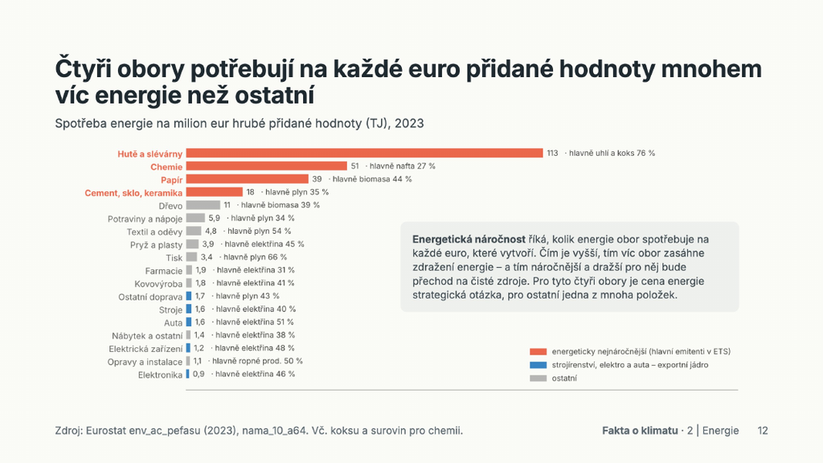

**PoznámkaCo jsou to za data**

*Eurostat PEFA (env_ac_pefa04) · 2023 (poslední rok) · TJ na mil. € HPH*

**Data:** Eurostat [`env_ac_pefa04`](https://ec.europa.eu/eurostat/databrowser/view/env_ac_pefa04/default/table) – čisté domácí užití energie pro energetické účely (`NETDOM_EUSE_EP`), TJ, ČR 2023 (poslední rok); HPH 2023 `nama_10_a64`. Skript: `R/12_energie_pefa.R`.

Od hrubého užití k energii (TJ na mil. € HPH): hrubé užití − suroviny − energie vyrobená v oboru ≈ energie pro energetické účely.

**Kód**

```r
e11 <- out("energie_narocnost_2023")
ep_raw <- es("env_ac_pefa04_ep") |> filter(time == 2023, indic_pefa == "NETDOM_EUSE_EP") |>
  transmute(nace = recode(nace_r2, "C10-C12" = "C10-12", "C13-C15" = "C13-15", "C31_C32" = "C31_32"), tj_es = values)
e11 |> filter(nace != "C") |> left_join(ep_raw, by = "nace") |>
  mutate(shoda = mapply(shoda, tj_energie, tj_es)) |>
  transmute(nace, obor = name, skupina, hrube = round(tj_hrube_na_mil_eur, 1),
            suroviny = round(tj_suroviny / hph_meur, 1), vlastni_vyroba = round(tj_vlastni_vyroba / hph_meur, 1),
            energie = round(tj_na_mil_eur, 1), hlavni_palivo, hlavni_podil_pct = round(hlavni_podil_pct), shoda) |>
  arrange(desc(energie))
```

| nace | obor | skupina | hrube | suroviny | vlastni_vyroba | energie | hlavni_palivo | hlavni_podil_pct | shoda |
| --- | --- | --- | --- | --- | --- | --- | --- | --- | --- |
| C24 | Hutě a slévárny | energeticky nejnáročnější | 113.2 | 0.1 | 49.9 | 63.2 | Uhlí a koks | 76 | TRUE |
| C20 | Chemie | energeticky nejnáročnější | 51.0 | 26.9 | 11.3 | 17.3 | Uhlí a koks | 32 | TRUE |
| C17 | Papír | energeticky nejnáročnější | 38.8 | 0.0 | 22.5 | 16.2 | Biomasa | 44 | TRUE |
| C23 | Cement, sklo, keramika | energeticky nejnáročnější | 17.9 | 0.0 | 3.1 | 14.8 | Zemní plyn | 35 | TRUE |
| C16 | Dřevo | ostatní | 10.8 | 0.1 | 3.1 | 7.6 | Biomasa | 39 | TRUE |
| C13-15 | Textil a oděvy | ostatní | 4.8 | 0.0 | 0.0 | 4.8 | Zemní plyn | 54 | TRUE |
| C22 | Pryž a plasty | ostatní | 3.9 | 0.0 | 0.1 | 3.8 | Elektřina | 45 | TRUE |
| C10-12 | Potraviny a nápoje | ostatní | 5.9 | 0.0 | 2.3 | 3.6 | Zemní plyn | 34 | TRUE |
| C18 | Tisk | ostatní | 3.4 | 0.0 | 0.0 | 3.4 | Zemní plyn | 66 | TRUE |
| C25 | Kovovýroba | ostatní | 1.8 | 0.0 | 0.0 | 1.8 | Elektřina | 41 | TRUE |
| C29 | Auta | exportní jádro | 1.6 | 0.0 | 0.0 | 1.6 | Elektřina | 51 | TRUE |
| C30 | Ostatní doprava | exportní jádro | 1.7 | 0.0 | 0.1 | 1.6 | Zemní plyn | 43 | TRUE |
| C28 | Stroje | exportní jádro | 1.6 | 0.0 | 0.0 | 1.6 | Elektřina | 40 | TRUE |
| C21 | Farmacie | ostatní | 1.9 | 0.0 | 0.3 | 1.6 | Elektřina | 31 | TRUE |
| C31_32 | Nábytek a ostatní | ostatní | 1.4 | 0.0 | 0.0 | 1.3 | Elektřina | 38 | TRUE |
| C27 | Elektrická zařízení | exportní jádro | 1.2 | 0.0 | 0.1 | 1.2 | Elektřina | 48 | TRUE |
| C33 | Opravy a instalace | ostatní | 1.1 | 0.0 | 0.0 | 1.1 | Ostatní ropné produkty | 50 | TRUE |
| C26 | Elektronika | exportní jádro | 0.9 | 0.0 | 0.1 | 0.8 | Elektřina | 46 | TRUE |

**Varianta bez uhlí a koksu (hutě).** Eurostat počítá koks ve vysoké peci jako energii (po odečtení vysokopecního plynu). Pokud ho chceme brát jako vstup (redukční činidlo), odečteme čisté užití uhlí a koksu = užití uhlí (P08, P09) a koksu (P11) − vlastní výroba energie v oboru (koks a plyny). Jde o dopočet, ne oficiální ukazatel.

**Kód**

```r
pefa_raw <- es("env_ac_pefasu_all")
c24 <- pefa_raw |> filter(nace_r2 == "C24")
uhli_koks <- sum(c24$values[c24$prod_nrg %in% c("P08", "P09", "P11")])
h24 <- e11 |> filter(nace == "C24")
tibble(energie_tj = h24$tj_energie, uhli_a_koks_tj = uhli_koks, vlastni_vyroba_tj = h24$tj_vlastni_vyroba,
       bez_koksu_tj = h24$tj_energie - (uhli_koks - h24$tj_vlastni_vyroba)) |>
  mutate(energie_na_mil_eur = round(energie_tj / h24$hph_meur, 1), bez_koksu_na_mil_eur = round(bez_koksu_tj / h24$hph_meur, 1))
```

| energie_tj | uhli_a_koks_tj | vlastni_vyroba_tj | bez_koksu_tj | energie_na_mil_eur | bez_koksu_na_mil_eur |
| --- | --- | --- | --- | --- | --- |
| 69866.3 | 95466.4 | 55141.6 | 29541.5 | 63.2 | 26.7 |

# S13 – Každý náročný obor běží na něčem jiném

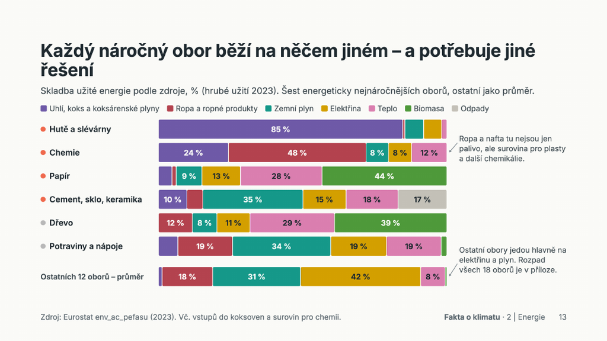

**PoznámkaCo jsou to za data**

*Eurostat PEFA (env_ac_pefasu) · 2023 · % hrubého užití energie*

**Data:** `out/energie_skladba7_2023.csv` (`R/12_energie_pefa.R`, tabulka `SKUPINY7`).

**Kód**

```r
out("energie_skladba7_2023") |> filter(podil_pct >= 0.5) |>
  mutate(podil_pct = round(podil_pct)) |> select(radek, skupina7, podil_pct) |>
  pivot_wider(names_from = skupina7, values_from = podil_pct, values_fill = 0)
```

| radek | Biomasa | Elektřina | Ropa a ropné produkty | Teplo | Uhlí, koks a koksárenské plyny | Zemní plyn | Odpady |
| --- | --- | --- | --- | --- | --- | --- | --- |
| C10-12 | 2 | 20 | 19 | 19 | 7 | 34 | 0 |
| C16 | 39 | 12 | 12 | 29 | 0 | 8 | 0 |
| C17 | 44 | 14 | 1 | 28 | 5 | 9 | 0 |
| C20 | 0 | 11 | 28 | 17 | 33 | 10 | 0 |
| C23 | 0 | 15 | 5 | 18 | 10 | 35 | 17 |
| C24 | 0 | 6 | 1 | 2 | 85 | 6 | 0 |
| ostatni | 1 | 42 | 17 | 8 | 1 | 31 | 0 |

# S15 – 72 % emisí kryto povolenkami zdarma

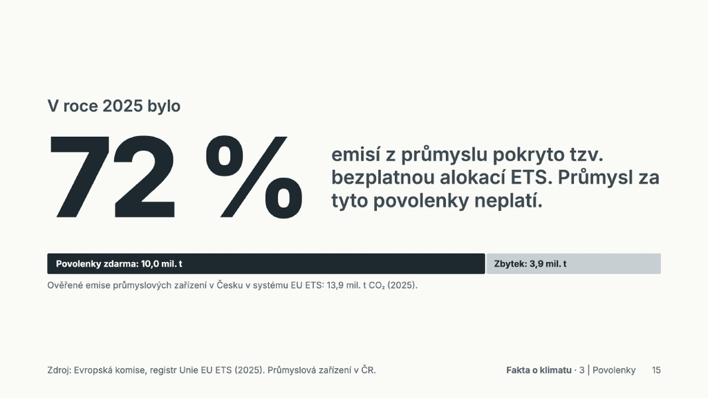

**PoznámkaCo jsou to za data**

*Registr EU ETS (Union Registry) · 2025 · tuny CO₂*

- **Ověřené emise** = emise zařízení za rok, ověřené auditorem.
- **Povolenky zdarma** = bezplatná alokace, kterou průmysl dostává kvůli ochraně před konkurencí ze zemí bez ceny uhlíku.
- Podíl 72 % = průmysl dostal zdarma povolenky na 72 % svých emisí; zbytek musí koupit.
- Z registru se berou jen **průmyslová** zařízení (bez elektráren a tepláren).

**Data:** [Union Registry – verified emissions 2025](https://climate.ec.europa.eu/eu-action/carbon-markets/eu-emissions-trading-system-eu-ets/union-registry_en) (`verified_emissions_2025_en.xlsx`, list `data`), průmyslová zařízení v ČR, rok 2025. Skript: `R/02_registry.R`.

**Krok 1 – od registru k průmyslu.** Z celého registru se berou stacionární zařízení v ČR. Která z nich jsou průmysl, určují ruční převodníky v `data/manual/`: kód činnosti → obor (`activity_to_nace.csv`), spalovací zdroje průmyslových podniků (`combustion_industrial.csv`) a ruční přeřazení (`installation_nace_override.csv`).

**Kód**

```r
raw <- read_excel(file.path(ROOT, "data/raw/verified_emissions_2025_en.xlsx"),
                  sheet = "data", skip = 2, col_types = "text")
cz  <- raw |> filter(REGISTRY_CODE == "CZ", ACCOUNT_TYPE == "OPERATOR HOLDING ACCOUNT") |>
  mutate(installation_id = as.integer(INSTALLATION_IDENTIFIER))

cz |> mutate(zarazeni = if_else(installation_id %in% i25$installation_id,
                                "průmysl (v analýze)", "mimo průmysl (energetika, teplárny…)")) |>
  group_by(zarazeni) |>
  summarise(zarizeni = n(), emise_2025_Mt = sum(num(VERIFIED_EMISSIONS_2025), na.rm = TRUE) / 1e6)
```

| zarazeni | zarizeni | emise_2025_Mt |
| --- | --- | --- |
| mimo průmysl (energetika, teplárny…) | 189 | 26.16362 |
| průmysl (v analýze) | 174 | 13.86468 |

**Krok 2 – podíl zdarma.** Bezplatná alokace (základní + z rezervy pro nové účastníky) / ověřené emise. Notebook ho počítá přímo ze surového registru a porovná s výstupem skriptu:

**Kód**

```r
z_registru <- cz |> filter(installation_id %in% i25$installation_id) |>
  summarise(zdarma = sum(num(ALLOCATION_2025), num(ALLOCATION_RESERVE_2025), na.rm = TRUE),
            emise  = sum(num(VERIFIED_EMISSIONS_2025), na.rm = TRUE))
ze_skriptu <- i25 |> summarise(zdarma = sum(free_alloc, na.rm = TRUE), emise = sum(verified_em, na.rm = TRUE))

tibble(velicina = c("povolenky zdarma (Mt)", "ověřené emise (Mt)", "podíl zdarma (%)"),
       registr  = c(z_registru$zdarma / 1e6, z_registru$emise / 1e6, z_registru$zdarma / z_registru$emise * 100),
       skript   = c(ze_skriptu$zdarma / 1e6, ze_skriptu$emise / 1e6, ze_skriptu$zdarma / ze_skriptu$emise * 100)) |>
  mutate(shoda = mapply(shoda, registr, skript))
```

| velicina | registr | skript | shoda |
| --- | --- | --- | --- |
| povolenky zdarma (Mt) | 10.04291 | 10.04291 | TRUE |
| ověřené emise (Mt) | 13.86468 | 13.86468 | TRUE |
| podíl zdarma (%) | 72.43517 | 72.43517 | TRUE |

# S16 – Podíl povolenek zdarma v jednotlivých oborech

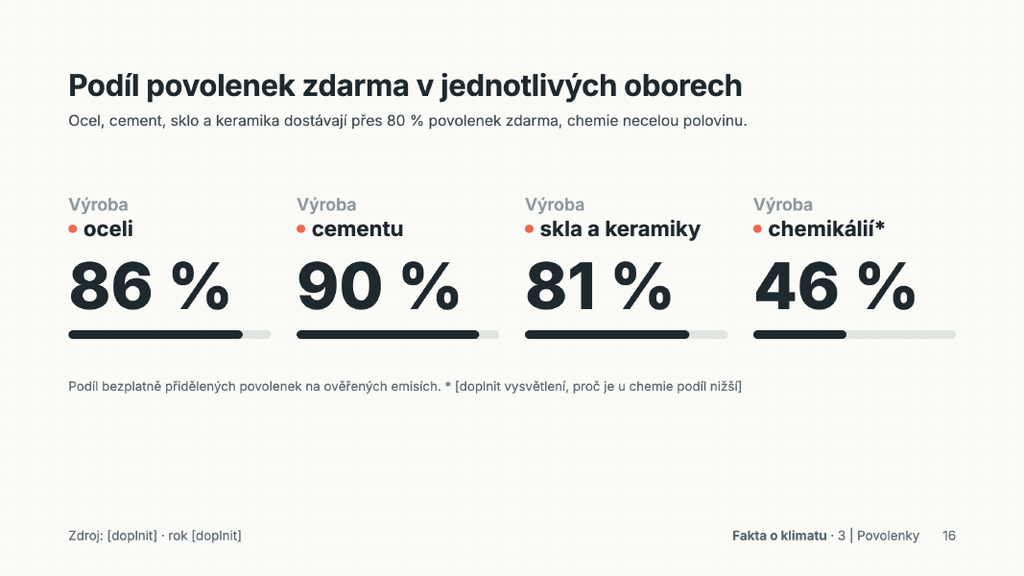

**PoznámkaCo jsou to za data**

*Registr EU ETS · 2025 · %*

- Stejný podíl jako S15, ale po sektorech. Cement = výroba slínku a vápna, sklo a keramika = ostatní zařízení oboru C23.

**Data:** jako S15. Vymezení sektorů: ocel = obor C24; cement = činnosti 29 (slínek) a 30 (vápno); sklo a keramika = zbytek C23; chemie = C20. Vymezení je ve sloupci `sektor` v `R/02_registry.R`.

**Kód**

```r
s16 <- i25 |> filter(!is.na(sektor)) |> group_by(sektor) |> podil_zdarma()
s16
```

| sektor | zarizeni | zdarma_kt | emise_kt | podil_pct |
| --- | --- | --- | --- | --- |
| Chemikálie | 21 | 2477.465 | 4809.806 | 51.50863 |
| Sklo a keramika | 64 | 811.311 | 999.350 | 81.18387 |
| Výroba cementu | 10 | 2467.453 | 2730.807 | 90.35618 |
| Výroba oceli | 25 | 3557.922 | 4103.003 | 86.71507 |

Zařízení po oborech (`proc` = podle procesní činnosti, `comb` = spalovací zdroj průmyslového podniku):

**Kód**

```r
i25 |> group_by(nace, source) |>
  summarise(zarizeni = n(), emise_kt = sum(verified_em, na.rm = TRUE) / 1e3, .groups = "drop") |>
  pivot_wider(names_from = source, values_from = c(zarizeni, emise_kt), values_fill = 0) |>
  arrange(desc(emise_kt_proc + emise_kt_comb))
```

| nace | zarizeni_comb | zarizeni_proc | emise_kt_comb | emise_kt_proc |
| --- | --- | --- | --- | --- |
| C20 | 10 | 11 | 3595.869 | 1213.937 |
| C24 | 11 | 14 | 1460.876 | 2642.127 |
| C23 | 5 | 69 | 76.064 | 3654.093 |
| C29 | 7 | 0 | 411.612 | 0.000 |
| C17 | 5 | 9 | 304.717 | 73.745 |
| C10-12 | 16 | 0 | 243.095 | 0.000 |
| C19 | 1 | 2 | 109.939 | 21.987 |
| C22 | 3 | 0 | 21.509 | 0.000 |
| C16 | 2 | 1 | 15.903 | 4.577 |
| C21 | 1 | 0 | 14.633 | 0.000 |
| C13-15 | 1 | 0 | 0.000 | 0.000 |
| C25 | 2 | 0 | 0.000 | 0.000 |
| C28 | 2 | 0 | 0.000 | 0.000 |
| C30 | 2 | 0 | 0.000 | 0.000 |

# S17 – Hlavní náklad je energie, ne povolenky

[figure not shown]

**PoznámkaCo jsou to za data**

*ČSÚ SUT 2024–25 + registr ETS 2024 + PEFA 2023 · % nákladů*

- **Nákupy energie** v % nákladů – ze SUT jako na S11.
- **Nepřímý náklad ETS** = o kolik povolenky zdražují elektřinu ze sítě: elektřina **ze sítě** (bez vlastní výroby) × 0,85 t CO₂/MWh × 65 €/t. Po odečtení **kompenzace**, kterou stát (MPO) vrací vybraným odvětvím (papír, hutě, chemie…). Horní odhad: maximální emisní faktor 0,85 t/MWh. Vlastní elektřinu (papírny ji z 58 % vyrábějí z černého louhu a biomasy) obor nekupuje a povolenku v ceně nenese.
- **Přímý čistý náklad ETS** = (ověřené emise − povolenky zdarma) × 65 €/t, **netto**: přebytky povolenek jednoho zařízení snižují náklad oboru (lze je prodat). Varianta jen s deficity je v tabulce.
- Všechno je v % stejných **celkových nákladů ze SUT** (mezispotřeba + náhrady zaměstnancům); pro ETS rok 2024, pro energii průměr 2024–25.
- Rafinerie Litvínov a Kralupy jsou v chemii – stejně jako v národních účtech (celý podnik ORLEN Unipetrol RPA je v C20).

**Na slajdu:** podíl oboru na nákladech průmyslu 2024; nákupy energie 2024–25 (% nákladů, SUT); nepřímé náklady ETS v ceně elektřiny (% nákladů); přímé čisté náklady ETS (% nákladů).

**Data:**

- energie: ČSÚ SUT (S11);
- jmenovatel pro ETS: celkové náklady oboru 2024 ze SUT ČSÚ (jako S11, jen rok 2024), převod kurzem ECB 2024 (25,12 Kč/€);
- registr (S15), elektřina [`env_ac_pefasu`](https://ec.europa.eu/eurostat/databrowser/view/env_ac_pefasu/default/table) P26 2023, cena povolenky [DEHSt](https://www.dehst.de/EN/Topics/EU-ETS-1/EU-ETS-1-Information/Auctioning/auctioning_node.html) 65,01 €/t;
- skript `R/03_ets_costs.R`.

**Vzorce**

- přímý = (ověřené emise − povolenky zdarma) × 65,01 €/t po zařízeních; horní odhad = všechna zařízení oboru vč. energetik podniků, nejlepší odhad = energetiky jen podílem výroby pro obor (Energetika Třinec 86,5 %);
- nepřímý = (elektřina − vlastní výroba) (TJ) / 3,6 × 1000 MWh × 0,85 t/MWh × 65,01 €/t (horní odhad, bez kompenzace); na snímku se od ní ještě odečítá kompenzace (`data/manual/kompenzace_neprimych_nakladu_2024.csv`); ostatní varianty jsou v tabulce pro srovnání. Vysvětlení: `docs/neprime_naklady_ets.md`.

Přepočet nákladů ETS v mil. € přímo z registru a PEFA:

**Kód**

```r
elec <- pefa_raw |> filter(prod_nrg == "P26") |>
  transmute(nace = recode(nace_r2, "C10-C12" = "C10-12", "C13-C15" = "C13-15", "C31_C32" = "C31_32"), elec_tj = values)
comb <- read_csv(file.path(MAN, "combustion_industrial.csv"), show_col_types = FALSE) |> select(installation_id, podil_obor)
prime <- inst |> filter(year == 2024) |> left_join(comb, by = "installation_id") |>
  mutate(net = coalesce(verified_em, 0) - coalesce(free_alloc, 0), podil_obor = coalesce(podil_obor, 1)) |>
  group_by(nace) |> summarise(net_t = sum(net), net_def_t = sum(pmax(net, 0)), net_best_t = sum(net * podil_obor))
prime <- bind_rows(prime, tibble(nace = "C", net_t = sum(prime$net_t), net_def_t = sum(prime$net_def_t), net_best_t = sum(prime$net_best_t)))

ets |> filter(nace != "C19") |>   # rafinerie: PEFA se pro ně nestahuje (vynechány ze slajdů)
  select(nace, obor = name, direct_meur, direct_best_meur, indirect_meur) |>
  left_join(elec, by = "nace") |> left_join(prime, by = "nace") |>
  mutate(prime_meur = net_t * EUA_2024 / 1e6, prime_best_meur = net_best_t * EUA_2024 / 1e6,
         nepr_meur = elec_tj / 3.6 * 1000 * EF_ELEC * EUA_2024 / 1e6,
         shoda = mapply(shoda, prime_meur, direct_meur) & mapply(shoda, prime_best_meur, direct_best_meur) &
                 mapply(shoda, nepr_meur, indirect_meur)) |>
  transmute(nace, obor, elektrina_TJ = elec_tj, netto_kt = round(net_t / 1e3, 1), jen_deficity_kt = round(net_def_t / 1e3, 1),
            prime_meur = round(prime_meur, 1), prime_best_meur = round(prime_best_meur, 1),
            nepr_meur = round(nepr_meur, 1), shoda)
```

| nace | obor | elektrina_TJ | netto_kt | jen_deficity_kt | prime_meur | prime_best_meur | nepr_meur | shoda |
| --- | --- | --- | --- | --- | --- | --- | --- | --- |
| C | Zpracovatelský průmysl celkem | 81429.1 | 3062.7 | 4659.0 | 199.1 | 181.8 | 1249.9 | TRUE |
| C10-12 | Potraviny a nápoje | 6646.0 | 119.0 | 136.4 | 7.7 | 7.7 | 102.0 | TRUE |
| C13-15 | Textil a oděvy | 2001.1 | 0.0 | 0.0 | 0.0 | 0.0 | 30.7 | TRUE |
| C16 | Dřevo | 1883.0 | -102.7 | 0.0 | -6.7 | -6.7 | 28.9 | TRUE |
| C17 | Papír | 6331.9 | 134.0 | 141.6 | 8.7 | 8.7 | 97.2 | TRUE |
| C18 | Tisk | 549.3 | NA | NA | NA | NA | 8.4 | TRUE |
| C20 | Chemie | 11105.0 | 2178.3 | 2374.0 | 141.6 | 140.5 | 170.5 | TRUE |
| C21 | Farmacie | 670.1 | 4.0 | 4.0 | 0.3 | 0.3 | 10.3 | TRUE |
| C22 | Pryž a plasty | 7250.7 | 16.1 | 16.1 | 1.0 | 1.0 | 111.3 | TRUE |
| C23 | Cement, sklo, keramika | 7558.0 | -12.0 | 227.7 | -0.8 | -0.8 | 116.0 | TRUE |
| C24 | Hutě a slévárny | 7981.2 | 370.0 | 1380.0 | 24.1 | 12.8 | 122.5 | TRUE |
| C25 | Kovovýroba | 5875.1 | 0.0 | 0.0 | 0.0 | 0.0 | 90.2 | TRUE |
| C26 | Elektronika | 1373.3 | NA | NA | NA | NA | 21.1 | TRUE |
| C27 | Elektrická zařízení | 3461.6 | NA | NA | NA | NA | 53.1 | TRUE |
| C28 | Stroje | 3816.1 | 0.0 | 0.0 | 0.0 | 0.0 | 58.6 | TRUE |
| C29 | Auta | 10990.7 | 373.1 | 373.1 | 24.3 | 19.4 | 168.7 | TRUE |
| C30 | Ostatní doprava | 788.7 | 0.0 | 0.0 | 0.0 | 0.0 | 12.1 | TRUE |
| C31_32 | Nábytek a ostatní | 1215.0 | NA | NA | NA | NA | 18.6 | TRUE |
| C33 | Opravy a instalace | 365.8 | NA | NA | NA | NA | 5.6 | TRUE |

Výsledek slajdu:

**Kód**

```r
ets |> transmute(nace, obor = name, podil_nakladu_prumyslu_pct = round(podil_nakladu_c_pct, 1),
                 nepr_ETS_po_kompenzaci_pct = round(indirect_net_pct_naklady, 1), nepr_ETS_sit_pct = round(indirect_best_pct_naklady, 1),
                 nepr_ETS_vc_vlastni_pct = round(indirect_pct_naklady, 1), prime_ETS_netto_pct = round(direct_pct_naklady, 2),
                 prime_ETS_nejlepsi_pct = round(direct_best_pct_naklady, 2), prime_ETS_jen_deficity_pct = round(direct_def_pct_naklady, 2)) |>
  left_join(sut |> transmute(nace, energie_pct = round(energie_pct, 1)), by = "nace") |>
  filter(nace != "C19") |> arrange(desc(energie_pct))
```

| nace | obor | podil_nakladu_prumyslu_pct | nepr_ETS_po_kompenzaci_pct | nepr_ETS_sit_pct | nepr_ETS_vc_vlastni_pct | prime_ETS_netto_pct | prime_ETS_nejlepsi_pct | prime_ETS_jen_deficity_pct | energie_pct |
| --- | --- | --- | --- | --- | --- | --- | --- | --- | --- |
| C24 | Hutě a slévárny | 4.0 | 0.8 | 1.2 | 1.5 | 0.29 | 0.16 | 1.09 | 15.5 |
| C20 | Chemie | 4.1 | 1.2 | 1.5 | 2.0 | 1.66 | 1.65 | 1.81 | 14.9 |
| C23 | Cement, sklo, keramika | 3.2 | 1.7 | 1.8 | 1.8 | -0.01 | -0.01 | 0.23 | 11.7 |
| C22 | Pryž a plasty | 5.9 | 0.9 | 0.9 | 0.9 | 0.01 | 0.01 | 0.01 | 5.4 |
| C17 | Papír | 1.9 | 0.3 | 1.0 | 2.4 | 0.22 | 0.22 | 0.23 | 5.1 |
| C10-12 | Potraviny a nápoje | 8.4 | 0.3 | 0.3 | 0.6 | 0.04 | 0.04 | 0.05 | 4.4 |
| C13-15 | Textil a oděvy | 1.4 | 1.0 | 1.0 | 1.0 | 0.00 | 0.00 | 0.00 | 4.4 |
| C16 | Dřevo | 1.8 | 0.7 | 0.7 | 0.8 | -0.17 | -0.17 | 0.00 | 4.1 |
| C | Zpracovatelský průmysl celkem | 100.0 | 0.5 | 0.5 | 0.6 | 0.10 | 0.09 | 0.15 | 4.0 |
| C25 | Kovovýroba | 8.5 | 0.5 | 0.5 | 0.5 | 0.00 | 0.00 | 0.00 | 4.0 |
| C27 | Elektrická zařízení | 7.1 | 0.4 | 0.4 | 0.4 | NA | NA | NA | 3.2 |
| C30 | Ostatní doprava | 2.0 | 0.3 | 0.3 | 0.3 | 0.00 | 0.00 | 0.00 | 3.0 |
| C21 | Farmacie | 1.0 | 0.5 | 0.5 | 0.5 | 0.01 | 0.01 | 0.01 | 2.9 |
| C18 | Tisk | 0.8 | 0.5 | 0.5 | 0.5 | NA | NA | NA | 2.7 |
| C28 | Stroje | 7.2 | 0.4 | 0.4 | 0.4 | 0.00 | 0.00 | 0.00 | 2.4 |
| C33 | Opravy a instalace | 2.9 | 0.1 | 0.1 | 0.1 | NA | NA | NA | 2.2 |
| C31_32 | Nábytek a ostatní | 2.4 | 0.4 | 0.4 | 0.4 | NA | NA | NA | 2.0 |
| C29 | Auta | 31.3 | 0.2 | 0.2 | 0.3 | 0.04 | 0.03 | 0.04 | 1.3 |
| C26 | Elektronika | 6.1 | 0.2 | 0.2 | 0.2 | NA | NA | NA | 1.2 |

*Pozn.:* Jmenovatel je pro energii i ETS stejný zdroj (SUT ČSÚ); energie je průměr 2024–25, ETS rok 2024. Elektřina pro nepřímý náklad je z PEFA 2023 (poslední rok). Nepřímý náklad je horní odhad: maximální emisní faktor 0,85 t/MWh a plné promítnutí ceny povolenky do ceny elektřiny.

# S19 – Exportnímu jádru nehrozí povolenky

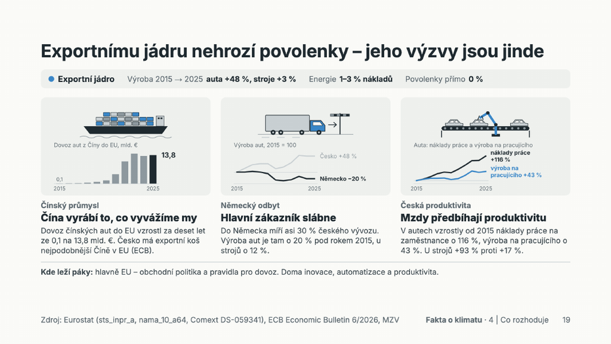

**PoznámkaCo jsou to za data**

*Eurostat národní účty, krátkodobá statistika, Comext · 2015–2025*

- **Podíl práce na přidané hodnotě** = náhrady zaměstnancům / HPH oboru. Kolik z vytvořené hodnoty jde na mzdy a odvody. Když roste, mzdy předbíhají produktivitu.
- Obě veličiny jsou ze stejného zdroje (národní účty) a ve stejných jednotkách (běžné €), takže inflace se vzájemně vyruší.
- Pro srovnání: náklady práce na zaměstnance a nominální HPH na pracujícího (2015 = 100).
- **Comext** = databáze zahraničního obchodu EU podle celních kódů; HS 8703 = osobní auta.

**Lišta:** výroba 2015 → 2025 (S9), energie (% nákladů, S11), povolenky přímo (S17).

**Kód**

```r
idx |> filter(nace %in% c("C26", "C27", "C28", "C29", "C30")) |>
  left_join(sut |> select(nace, energie_pct), by = "nace") |>
  left_join(ets |> select(nace, direct_pct_naklady), by = "nace") |>
  transmute(nace, vyroba_CZ_pct = round(CZ), vyroba_DE_pct = round(DE),
            energie_pct = round(energie_pct, 1), prime_ETS_pct = round(direct_pct_naklady, 1))
```

| nace | vyroba_CZ_pct | vyroba_DE_pct | energie_pct | prime_ETS_pct |
| --- | --- | --- | --- | --- |
| C26 | 25 | 22 | 1.2 | NA |
| C27 | 39 | -10 | 3.2 | NA |
| C28 | 3 | -12 | 2.4 | 0 |
| C29 | 48 | -20 | 1.3 | 0 |
| C30 | 44 | 48 | 3.0 | 0 |

**Karta 1 – dovoz aut z Číny do EU.** Eurostat Comext [DS-059341](https://ec.europa.eu/eurostat/comext/newxtweb/): dovoz do EU27 z Číny, HS 8703 (osobní auta), €.

**Kód**

```r
out("dovoz_aut_cina_eu") |> mutate(dovoz_mld_eur = round(dovoz_mld_eur, 1))
```

| rok | dovoz_mld_eur |
| --- | --- |
| 2015 | 0.1 |
| 2016 | 0.1 |
| 2017 | 0.4 |
| 2018 | 0.4 |
| 2019 | 0.8 |
| 2020 | 1.6 |
| 2021 | 4.6 |
| 2022 | 10.7 |
| 2023 | 14.5 |
| 2024 | 13.3 |
| 2025 | 13.9 |

**Karta 2 – Německo.** Index výroby, Německo 2015 → 2025 (S9): auta a stroje.

**Kód**

```r
idx |> filter(nace %in% c("C28", "C29")) |> transmute(nace, vyroba_DE_pct = round(DE))
```

| nace | vyroba_DE_pct |
| --- | --- |
| C28 | -12 |
| C29 | -20 |

**Karta 3 – mzdy vs. produktivita.** Hlavní ukazatel: podíl náhrad zaměstnancům `D1` na HPH `B1G` (`nama_10_a64`). Pro srovnání náklady práce na zaměstnance (`D1` / `SAL_DC`) a nominální HPH na pracujícího (`B1G` / `EMP_DC`, `nama_10_a64_e`), obojí 2015 = 100. Skript: `R/11_hph_zamestnanost.R`. Dřívější „výroba na pracujícího“ (objemový index) se s nominálními mzdami nedala férově srovnat – je v tabulce pro úplnost.

**Kód**

```r
prace <- out("exportni_jadro_prace")
prace |> filter(time %in% c(2015, 2025)) |>
  transmute(nace, rok = time, D1_meur = D1, HPH_meur = B1G, podil_prace_na_HPH_pct = round(podil_prace_hph, 1),
            naklady_prace_na_zam_idx = round(naklady_prace_idx), HPH_na_prac_nominal_idx = round(hph_na_prac_idx),
            vyroba_na_prac_objem_idx = round(vyroba_na_prac_idx))
```

| nace | rok | D1_meur | HPH_meur | podil_prace_na_HPH_pct | naklady_prace_na_zam_idx | HPH_na_prac_nominal_idx | vyroba_na_prac_objem_idx |
| --- | --- | --- | --- | --- | --- | --- | --- |
| C28 | 2015 | 2208.8 | 3842.8 | 57.5 | 100 | 100 | 100 |
| C29 | 2015 | 3206.0 | 7775.7 | 41.2 | 100 | 100 | 100 |
| C28 | 2025 | 3796.3 | 5536.8 | 68.6 | 193 | 163 | 117 |
| C29 | 2025 | 7151.5 | 13750.2 | 52.0 | 216 | 171 | 143 |

# S20 – Cement a cihly

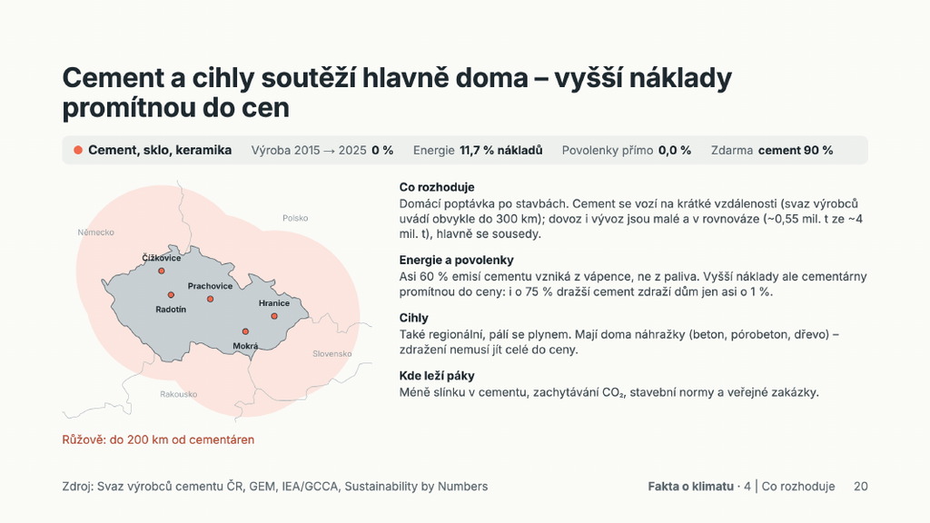

**PoznámkaCo jsou to za data**

*souhrn ze S9, S11, S16, S17*

- Lišta slajdu: výroba 2015 → 2025 (index objemu), energie (% nákladů, SUT), povolenky přímo (% nákladů), povolenky zdarma (%). Texty karet jsou z rešerše.

**Lišta:** výroba 2015 → 2025 (S9), energie (% nákladů, S11), povolenky přímo (S17), povolenky zdarma pro cement (S16). Text karet je z rešerše (zdroje na slajdu).

**Kód**

```r
karta <- function(n, sektor) tibble(
  obor = NACE_NAMES_NB[[n]],
  vyroba_2015_2025_pct = round(idx$CZ[idx$nace == n]),
  energie_pct          = round(sut$energie_pct[sut$nace == n], 1),
  prime_ETS_pct        = round(ets$direct_pct_naklady[ets$nace == n], 1),
  prime_ETS_nejlepsi_pct = round(ets$direct_best_pct_naklady[ets$nace == n], 1),
  zdarma_pct           = round(s16$podil_pct[s16$sektor == sektor], 1))
NACE_NAMES_NB <- setNames(sut$name, sut$nace)
karta("C23", "Výroba cementu")
```

| obor | vyroba_2015_2025_pct | energie_pct | prime_ETS_pct | prime_ETS_nejlepsi_pct | zdarma_pct |
| --- | --- | --- | --- | --- | --- |
| Cement, sklo, keramika | 0 | 11.7 | 0 | 0 | 90.4 |

# S21 – Ocel

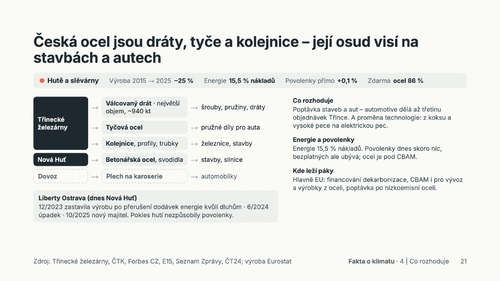

**PoznámkaCo jsou to za data**

*souhrn ze S9, S11, S16, S17 + registr podle závodů*

- Stejná lišta jako S20. Emise podle závodů ukazují, že pokles hutí způsobilo zastavení Liberty Ostrava, ne povolenky.

**Kód**

```r
karta("C24", "Výroba oceli")
```

| obor | vyroba_2015_2025_pct | energie_pct | prime_ETS_pct | prime_ETS_nejlepsi_pct | zdarma_pct |
| --- | --- | --- | --- | --- | --- |
| Hutě a slévárny | -25 | 15.5 | 0.3 | 0.2 | 86.7 |

Emise hutí podle závodů (Ostrava = Liberty + TAMEH, Třinec = TŽ + Energetika Třinec), kt:

**Kód**

```r
out("steel_sites") |> filter(year >= 2019) |>
  select(site, year, verified_kt) |> pivot_wider(names_from = year, values_from = verified_kt)
```

| site | 2019 | 2020 | 2021 | 2022 | 2023 | 2024 | 2025 |
| --- | --- | --- | --- | --- | --- | --- | --- |
| Ostrava | 4435.918 | 4041.115 | 5178.873 | 4213.529 | 2433.206 | 48.583 | 0.000 |
| Třinec | 4222.261 | 4389.415 | 4039.783 | 4028.910 | 3955.038 | 3910.968 | 3841.283 |
| ostatní | 368.665 | 319.204 | 313.863 | 271.544 | 257.279 | 258.844 | 261.720 |

# S22 – Chemie

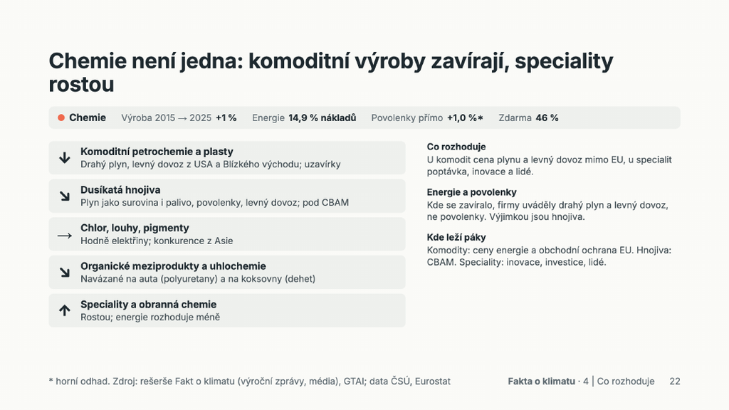

**PoznámkaCo jsou to za data**

*souhrn ze S9, S11, S16, S17*

- Stejná lišta jako S20. U chemie je přímý náklad horní odhad (vč. elektráren a kotelen podniků).

**Kód**

```r
karta("C20", "Chemikálie")
```

| obor | vyroba_2015_2025_pct | energie_pct | prime_ETS_pct | prime_ETS_nejlepsi_pct | zdarma_pct |
| --- | --- | --- | --- | --- | --- |
| Chemie | 1 | 14.9 | 1.7 | 1.6 | 51.5 |

**Chemie není jedna: skupina ORLEN Unipetrol vs. ostatní chemie.** Zařízení skupiny ORLEN Unipetrol v registru EU ETS (rafinerie Litvínov a Kralupy, petrochemie, agrochemie, Spolana; vyhledáno podle názvu provozovatele), rok 2024.

**Kód**

```r
i24 <- inst |> filter(year == 2024, nace == "C20") |>
  mutate(cast = if_else(grepl("UNIPETROL|ORLEN|SPOLANA", toupper(name)), "ORLEN Unipetrol", "ostatní chemie"))
i24 |> group_by(cast) |>
  summarise(zarizeni = n(), emise_kt = round(sum(verified_em, na.rm = TRUE) / 1e3),
            zdarma_pct = round(sum(free_alloc, na.rm = TRUE) / sum(verified_em, na.rm = TRUE) * 100),
            deficit_kt = round(sum(verified_em - free_alloc, na.rm = TRUE) / 1e3),
            deficit_mil_eur = round(sum(verified_em - free_alloc, na.rm = TRUE) * EUA_2024 / 1e6, 1)) |>
  mutate(podil_na_emisich_chemie_pct = round(emise_kt / sum(emise_kt) * 100))
```

| cast | zarizeni | emise_kt | zdarma_pct | deficit_kt | deficit_mil_eur | podil_na_emisich_chemie_pct |
| --- | --- | --- | --- | --- | --- | --- |
| ORLEN Unipetrol | 5 | 3530 | 52 | 1689 | 109.8 | 72 |
| ostatní chemie | 16 | 1407 | 65 | 489 | 31.8 | 28 |

Kontrola proti výkazu firmy: náklady na povolenky, které skupina sama vykazuje (konsolidovaná závěrka, ručně přepsáno do `data/manual/unipetrol_vykazy.csv` s odkazem), vs. odhad z registru (deficit × průměrná cena aukcí 2024 × kurz ECB).

**Kód**

```r
vykaz <- read_csv(file.path(MAN, "unipetrol_vykazy.csv"), show_col_types = FALSE)
odhad_mil_kc <- i24 |> filter(cast == "ORLEN Unipetrol") |>
  summarise(v = sum(verified_em - free_alloc, na.rm = TRUE) * EUA_2024 * 25.12 / 1e6) |> pull(v)
tibble(vykaz_firmy_mil_kc = vykaz$mil_kc[vykaz$polozka == "naklady_co2_povolenky_netto" & vykaz$rok == 2024],
       odhad_z_registru_mil_kc = round(odhad_mil_kc),
       podil_co2_na_nakladech_firmy_pct = round(vykaz$mil_kc[vykaz$polozka == "naklady_co2_povolenky_netto" & vykaz$rok == 2024] /
                                                vykaz$mil_kc[vykaz$polozka == "naklady_podle_druhu_celkem" & vykaz$rok == 2024] * 100, 1))
```

| vykaz_firmy_mil_kc | odhad_z_registru_mil_kc | podil_co2_na_nakladech_firmy_pct |
| --- | --- | --- |
| 3546 | 2758 | 2.1 |

*Pozn.:* Náklady firmy obsahují i maloobchod (čerpací stanice), PARAMO a zahraniční dcery, proto je podíl CO₂ na jejích nákladech jen orientační. Nákladovou stranu „ostatní chemie“ (obor C20 minus Unipetrol) z veřejných dat čistě oddělit nejde: konsolidovaná závěrka nerozlišuje rafinerii, petrochemii a maloobchod v členění národních účtů.

# S23 – Každý segment čelí jiné výzvě

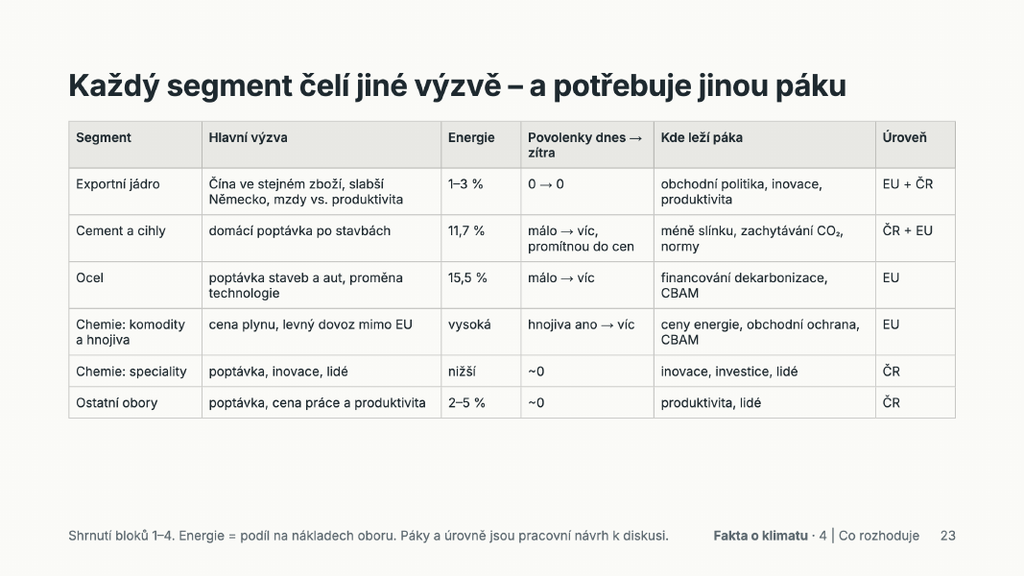

**PoznámkaCo jsou to za data**

*souhrn S11–S22*

- Z dat je jen sloupec **Energie** (% nákladů, SUT ČSÚ 2024–25). Výzvy, páky a úrovně jsou pracovní návrh autorů.

**Kód**

```r
sut23 <- out("naklady_sut") |> filter(nace != "C")
rozpeti <- function(n) { e <- sut23$energie_pct[sut23$nace %in% n]; sprintf("%.0f–%.0f %%", min(e), max(e)) }
tibble(segment = c("Exportní jádro (C26–C30)", "Cement, sklo, keramika (C23)", "Ocel – hutě (C24)", "Chemie (C20)", "Ostatní obory"),
       energie = c(rozpeti(c("C26", "C27", "C28", "C29", "C30")),
                   sprintf("%.1f %%", sut23$energie_pct[sut23$nace == "C23"]),
                   sprintf("%.1f %%", sut23$energie_pct[sut23$nace == "C24"]),
                   sprintf("%.1f %%", sut23$energie_pct[sut23$nace == "C20"]),
                   rozpeti(setdiff(sut23$nace, c("C26", "C27", "C28", "C29", "C30", "C23", "C24", "C20", "C17")))))
```

| segment | energie |
| --- | --- |
| Exportní jádro (C26–C30) | 1–3 % |
| Cement, sklo, keramika (C23) | 11.7 % |
| Ocel – hutě (C24) | 15.5 % |
| Chemie (C20) | 14.9 % |
| Ostatní obory | 2–5 % |

*Pozn.:* Papír (5,1 %) je energeticky náročný, ale v tabulce segmentů samostatně není.

# S25 – Příloha: skladba užité energie ve všech 18 oborech

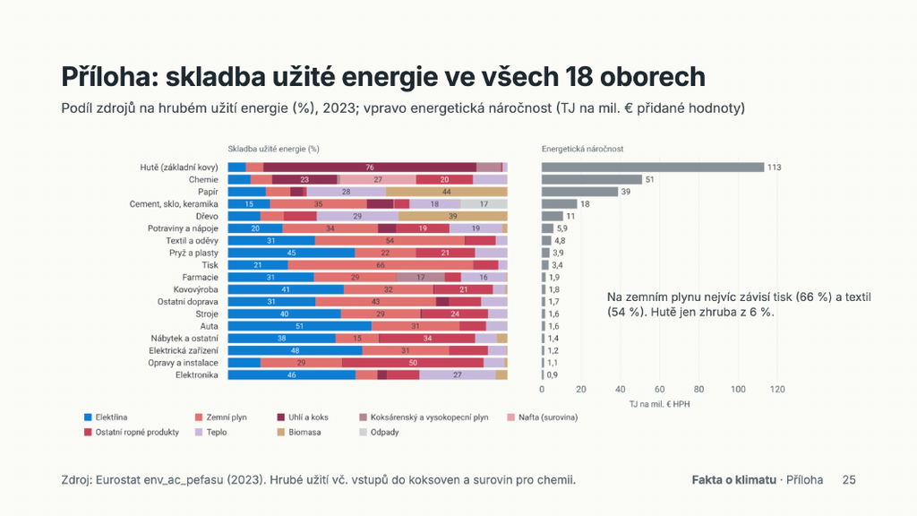

**PoznámkaCo jsou to za data**

*Eurostat PEFA · 2023 · % užité energie*

**Kód**

```r
out("energie_skladba_2023") |> filter(nace != "C", tj > 0) |>
  mutate(podil_pct = round(podil_pct)) |> select(nace, palivo, podil_pct) |>
  pivot_wider(names_from = palivo, values_from = podil_pct, values_fill = 0) |>
  left_join(e11 |> select(nace, tj_na_mil_eur), by = "nace") |>
  arrange(desc(tj_na_mil_eur)) |> mutate(tj_na_mil_eur = round(tj_na_mil_eur, 1))
```

| nace | Biomasa | Elektřina | Ostatní ropné produkty | Teplo | Uhlí a koks | Zemní plyn | Koksárenský a vysokopecní plyn | Odpady | tj_na_mil_eur |
| --- | --- | --- | --- | --- | --- | --- | --- | --- | --- |
| C24 | 0 | 6 | 1 | 2 | 76 | 6 | 9 | 0 | 63.2 |
| C20 | 0 | 11 | 28 | 17 | 32 | 10 | 1 | 0 | 17.3 |
| C17 | 44 | 14 | 1 | 28 | 5 | 9 | 0 | 0 | 16.2 |
| C23 | 0 | 15 | 5 | 18 | 10 | 35 | 0 | 17 | 14.8 |
| C16 | 39 | 12 | 12 | 29 | 0 | 8 | 0 | 0 | 7.6 |
| C13-15 | 0 | 31 | 11 | 4 | 0 | 54 | 0 | 0 | 4.8 |
| C22 | 0 | 45 | 21 | 12 | 0 | 22 | 0 | 0 | 3.8 |
| C10-12 | 2 | 20 | 19 | 19 | 7 | 34 | 0 | 0 | 3.6 |
| C18 | 0 | 21 | 9 | 3 | 0 | 66 | 0 | 0 | 3.4 |
| C25 | 1 | 41 | 21 | 4 | 1 | 32 | 0 | 0 | 1.8 |
| C29 | 0 | 51 | 9 | 8 | 0 | 31 | 0 | 0 | 1.6 |
| C30 | 0 | 31 | 12 | 9 | 5 | 43 | 0 | 0 | 1.6 |
| C28 | 0 | 40 | 24 | 7 | 1 | 29 | 0 | 0 | 1.6 |
| C21 | 1 | 31 | 6 | 16 | 0 | 29 | 17 | 0 | 1.6 |
| C31_32 | 4 | 38 | 34 | 8 | 0 | 15 | 0 | 0 | 1.3 |
| C27 | 0 | 48 | 14 | 6 | 0 | 31 | 0 | 0 | 1.2 |
| C33 | 1 | 12 | 50 | 8 | 0 | 29 | 0 | 0 | 1.1 |
| C26 | 4 | 46 | 12 | 27 | 3 | 8 | 0 | 0 | 0.8 |

# Doplňkové analýzy (v decku v1 nejsou)

Dovozní konkurence a vývoz mimo EU ETS z FIGARO; používá je i kontrola exportního jádra u S7.

# D1 – Dovozní penetrace (v decku v1 není)

*Snímek v decku v1 není – doplňková analýza.*

**PoznámkaCo jsou to za data**

*Eurostat FIGARO · 2024 · mil. € (základní ceny)*

- **Dovozní penetrace** = jak velkou část toho, co se v Česku spotřebuje z výrobků oboru, pokryje dovoz. 86 % u elektroniky = jen 14 % domácí spotřeby pokryje česká výroba.
- **Domácí spotřeba** = produkce − vývoz + dovoz.
- Dovoz je rozdělený na dovoz z EU a mimo EU (tam míří CBAM).

**Data:** Eurostat FIGARO [`naio_10_fcp_ii4`](https://ec.europa.eu/eurostat/web/esa-supply-use-input-tables/database), mezinárodní input-output tabulka odvětví × odvětví, 2024, mil. €. Skript: `R/14_figaro.R`.

**Vzorce** (pro obor X, sečteno přes všechna užití vč. konečné poptávky):

- produkce P = dodávky oboru X z ČR kamkoli (`c_orig = CZ`);
- vývoz E = dodávky z ČR do zahraničí (`c_dest ≠ CZ`);
- dovoz M = výrobky oboru X ze zahraničí užité v ČR (`c_orig ≠ CZ`, `c_dest = CZ`);
- dovozní penetrace = M / (P − E + M); rozdělení na dovoz z EU27 a mimo EU.

Přepočet pro hutě přímo ze stažené tabulky:

**Kód**

```r
z_cz  <- es("figaro_2024_z_cz")  |> filter(ind_ava == "C24")
do_cz <- es("figaro_2024_do_cz") |> filter(ind_ava == "C24", c_orig != "CZ")
P <- sum(z_cz$values); E <- sum(z_cz$values[z_cz$c_dest != "CZ"]); M <- sum(do_cz$values)
fo <- out("figaro_obory")
tibble(P, E, M, penetrace_pct = M / (P - E + M) * 100,
       shoda = shoda(M / (P - E + M) * 100, fo$penetrace_pct[fo$nace == "C24" & fo$rok == 2024]))
```

| P | E | M | penetrace_pct | shoda |
| --- | --- | --- | --- | --- |
| 8506.832 | 4141.139 | 8706.852 | 66.60411 | TRUE |

Nezávislý přepočet všech oborů včetně rozdělení dovozu na EU a mimo EU a vývozu mimo oblast EU ETS (vlastní seznam zemí; Řecko má ve FIGARO kód `EL`):

**Kód**

```r
eu <- c("AT", "BE", "BG", "CY", "CZ", "DE", "DK", "EE", "EL", "ES", "FI", "FR", "HR", "HU", "IE", "IT", "LT",
        "LU", "LV", "MT", "NL", "PL", "PT", "RO", "SE", "SI", "SK")
z_all  <- es("figaro_2024_z_cz"); do_all <- es("figaro_2024_do_cz") |> filter(c_orig != "CZ")
stopifnot(all(eu %in% z_all$c_dest))   # každá země EU má ve FIGARO svůj kód
nb <- z_all |> group_by(nace = ind_ava) |>
  summarise(P = sum(values), E = sum(values[c_dest != "CZ"]),
            E_mimo = sum(values[!c_dest %in% c(eu, "NO", "IS", "LI", "CH", "UK")])) |>
  inner_join(do_all |> group_by(nace = ind_ava) |> summarise(M = sum(values), M_eu = sum(values[c_orig %in% eu])), by = "nace") |>
  mutate(pen = M / (P - E + M) * 100, pen_mimo_eu = (M - M_eu) / (P - E + M) * 100, mimo_ets = E_mimo / P * 100)
fo |> filter(rok == 2024) |> inner_join(nb, by = "nace") |>
  transmute(nace, penetrace = round(penetrace_pct, 1), mimo_eu = round(pen_mimo_eu_pct, 1), vyvoz_mimo_ets = round(mimo_ets_pct, 1),
            shoda = mapply(shoda, penetrace_pct, pen) & mapply(shoda, pen_mimo_eu_pct, pen_mimo_eu) & mapply(shoda, mimo_ets_pct, mimo_ets))
```

| nace | penetrace | mimo_eu | vyvoz_mimo_ets | shoda |
| --- | --- | --- | --- | --- |
| C10-12 | 44.2 | 6.8 | 5.1 | TRUE |
| C13-15 | 72.0 | 36.8 | 12.5 | TRUE |
| C16 | 28.7 | 5.9 | 8.4 | TRUE |
| C17 | 68.7 | 10.1 | 20.8 | TRUE |
| C18 | 12.6 | 4.3 | 3.8 | TRUE |
| C19 | 95.1 | 7.0 | 5.8 | TRUE |
| C20 | 54.2 | 14.5 | 9.8 | TRUE |
| C21 | 63.6 | 21.2 | 6.0 | TRUE |
| C22 | 59.1 | 14.5 | 17.2 | TRUE |
| C23 | 31.3 | 8.0 | 10.7 | TRUE |
| C24 | 66.6 | 11.4 | 7.6 | TRUE |
| C25 | 43.1 | 9.2 | 9.9 | TRUE |
| C26 | 85.9 | 56.2 | 23.6 | TRUE |
| C27 | 67.8 | 23.1 | 19.2 | TRUE |
| C28 | 71.2 | 18.4 | 21.7 | TRUE |
| C29 | 53.7 | 13.0 | 11.9 | TRUE |
| C30 | 45.4 | 18.7 | 17.8 | TRUE |
| C31_32 | 69.2 | 20.1 | 14.3 | TRUE |
| C33 | 11.0 | 3.0 | 5.5 | TRUE |

Výsledek (dřevo a papír sloučené jako na slajdu):

**Kód**

```r
fs <- out("figaro_skupiny")
fs |> filter(rok == 2024, !nace %in% c("C18", "C19_20", "C21", "C31_32", "C33")) |>
  bind_rows(fo |> filter(rok == 2024, nace == "C20")) |>
  transmute(nace, obor = coalesce(name, nace), penetrace_pct = round(penetrace_pct), z_EU_pct = round(pen_eu_pct),
            mimo_EU_pct = round(pen_mimo_eu_pct)) |>
  arrange(desc(penetrace_pct))
```

| nace | obor | penetrace_pct | z_EU_pct | mimo_EU_pct |
| --- | --- | --- | --- | --- |
| C26 | Elektronika | 86 | 30 | 56 |
| C13-15 | Textil a oděvy | 72 | 35 | 37 |
| C28 | Stroje | 71 | 53 | 18 |
| C27 | Elektrická zařízení | 68 | 45 | 23 |
| C24 | Hutě a slévárny | 67 | 55 | 11 |
| C22 | Pryž a plasty | 59 | 45 | 14 |
| C29 | Auta | 54 | 41 | 13 |
| C20 | Chemie | 54 | 40 | 15 |
| C16_17 | Dřevo a papír | 48 | 40 | 8 |
| C30 | Ostatní doprava | 45 | 27 | 19 |
| C10-12 | Potraviny a nápoje | 44 | 37 | 7 |
| C25 | Kovovýroba | 43 | 34 | 9 |
| C23 | Cement, sklo, keramika | 31 | 23 | 8 |

# D2 – Energetická náročnost vs. dovoz (v decku v1 není)

*Snímek v decku v1 není – doplňková analýza.*

**PoznámkaCo jsou to za data**

*FIGARO 2015 a 2024 + Eurostat PEFA (čisté užití) 2015 a 2023*

- Osa x = dovozní penetrace (D1), osa y = energetická náročnost.
- Energie je stejná jako na S12: čisté užití pro energetické účely.
- Prahy 10 TJ / mil. € a 50 % dělí obory do čtyř skupin.

**Data:** dovozní penetrace FIGARO 2015 ([`naio_10_fcp_ii2`](https://ec.europa.eu/eurostat/web/esa-supply-use-input-tables/database)) a 2024 (D1); energie = **čisté užití pro energetické účely** (`NETDOM_EUSE_EP`, stejně jako S12), Eurostat [`env_ac_pefa04`](https://ec.europa.eu/eurostat/databrowser/view/env_ac_pefa04/default/table), 2015 a 2023, na mil. € HPH; velikost = HPH. Rafinerie a chemie sloučené (zlom v národních účtech 2018), dřevo a papír sloučené. Prahy: 10 TJ / mil. € HPH a 50 % dovozní penetrace.

**Kód**

```r
fs |> transmute(nace, obor = name, rok, penetrace_pct = round(penetrace_pct, 1), rok_energie,
                tj_na_mil_eur = round(tj_na_mil_eur, 1), hph_meur, kvadrant) |>
  arrange(nace, rok)
```

| nace | obor | rok | penetrace_pct | rok_energie | tj_na_mil_eur | hph_meur | kvadrant |
| --- | --- | --- | --- | --- | --- | --- | --- |
| C10-12 | Potraviny a nápoje | 2015 | 40.1 | 2015 | 5.1 | 3246.6 | nenáročné, regionální trh |
| C10-12 | Potraviny a nápoje | 2024 | 44.2 | 2023 | 3.6 | 5826.7 | nenáročné, regionální trh |
| C13-15 | Textil a oděvy | 2015 | 72.7 | 2015 | 6.2 | 927.5 | obchodované, nenáročné |
| C13-15 | Textil a oděvy | 2024 | 72.0 | 2023 | 4.8 | 1265.1 | obchodované, nenáročné |
| C16_17 | Dřevo a papír | 2015 | 47.2 | 2015 | 17.5 | 1592.4 | náročné, regionální trh |
| C16_17 | Dřevo a papír | 2024 | 47.7 | 2023 | 11.4 | 2514.1 | náročné, regionální trh |
| C18 | Tisk | 2015 | 11.1 | 2015 | 2.5 | 511.4 | nenáročné, regionální trh |
| C18 | Tisk | 2024 | 12.6 | 2023 | 3.4 | 710.5 | nenáročné, regionální trh |
| C19_20 | Rafinerie a chemie | 2015 | 68.5 | 2015 | 45.6 | 1662.0 | náročné + silná dovozní konkurence |
| C19_20 | Rafinerie a chemie | 2024 | 61.7 | 2023 | 20.8 | 1885.0 | náročné + silná dovozní konkurence |
| C21 | Farmacie | 2015 | 61.3 | 2015 | 2.3 | 658.0 | obchodované, nenáročné |
| C21 | Farmacie | 2024 | 63.6 | 2023 | 1.6 | 1116.8 | obchodované, nenáročné |
| C22 | Pryž a plasty | 2015 | 57.8 | 2015 | 5.0 | 3197.9 | obchodované, nenáročné |
| C22 | Pryž a plasty | 2024 | 59.1 | 2023 | 3.8 | 3973.5 | obchodované, nenáročné |
| C23 | Cement, sklo, keramika | 2015 | 35.0 | 2015 | 24.8 | 1877.7 | náročné, regionální trh |
| C23 | Cement, sklo, keramika | 2024 | 31.3 | 2023 | 14.8 | 2574.1 | náročné, regionální trh |
| C24 | Hutě a slévárny | 2015 | 66.3 | 2015 | 62.8 | 1509.2 | náročné + silná dovozní konkurence |
| C24 | Hutě a slévárny | 2024 | 66.6 | 2023 | 63.2 | 1136.2 | náročné + silná dovozní konkurence |
| C25 | Kovovýroba | 2015 | 42.9 | 2015 | 3.1 | 4584.2 | nenáročné, regionální trh |
| C25 | Kovovýroba | 2024 | 43.1 | 2023 | 1.8 | 7939.3 | nenáročné, regionální trh |
| C26 | Elektronika | 2015 | 81.5 | 2015 | 1.1 | 2305.9 | obchodované, nenáročné |
| C26 | Elektronika | 2024 | 85.9 | 2023 | 0.8 | 3090.9 | obchodované, nenáročné |
| C27 | Elektrická zařízení | 2015 | 63.3 | 2015 | 2.0 | 3145.9 | obchodované, nenáročné |
| C27 | Elektrická zařízení | 2024 | 67.8 | 2023 | 1.2 | 5647.5 | obchodované, nenáročné |
| C28 | Stroje | 2015 | 70.9 | 2015 | 2.8 | 3842.8 | obchodované, nenáročné |
| C28 | Stroje | 2024 | 71.2 | 2023 | 1.6 | 5515.8 | obchodované, nenáročné |
| C29 | Auta | 2015 | 59.5 | 2015 | 2.4 | 7775.7 | obchodované, nenáročné |
| C29 | Auta | 2024 | 53.7 | 2023 | 1.6 | 14642.3 | obchodované, nenáročné |
| C30 | Ostatní doprava | 2015 | 51.0 | 2015 | 1.9 | 898.8 | obchodované, nenáročné |
| C30 | Ostatní doprava | 2024 | 45.4 | 2023 | 1.6 | 1900.0 | nenáročné, regionální trh |
| C31_32 | Nábytek a ostatní | 2015 | 57.1 | 2015 | 4.1 | 1299.9 | obchodované, nenáročné |
| C31_32 | Nábytek a ostatní | 2024 | 69.2 | 2023 | 1.3 | 2255.5 | obchodované, nenáročné |
| C33 | Opravy a instalace | 2015 | 17.0 | 2015 | 1.5 | 1436.9 | nenáročné, regionální trh |
| C33 | Opravy a instalace | 2024 | 11.0 | 2023 | 1.1 | 2831.4 | nenáročné, regionální trh |

# D3 – Vývoz mimo EU ETS (v decku v1 není)

*Snímek v decku v1 není – doplňková analýza.*

**PoznámkaCo jsou to za data**

*Eurostat FIGARO · 2024 · % produkce oboru*

- **Vývoz mimo oblast EU ETS** = do zemí, kde se za emise neplatí stejně (mimo EU, Norsko, Island, Lichtenštejnsko a Švýcarsko). CBAM tento vývoz nechrání.
- Spojené království je zvlášť: má vlastní ETS a CBAM zavádí od 2027.

**Data:** FIGARO 2024 (D1). Vývoz mimo oblast EU ETS = vývoz mimo EU27, Norsko, Island, Lichtenštejnsko a Švýcarsko; Spojené království zvlášť; vše v % produkce oboru. Tisk a rafinerie vynechány.

**Kód**

```r
fo |> filter(rok == 2024, !nace %in% c("C18", "C19")) |>
  transmute(nace, obor = name, mimo_ets_pct = round(mimo_ets_pct), uk_pct = round(uk_pct),
            objem_mld_eur = round(mimo_ets_uk_mld, 1)) |>
  arrange(desc(mimo_ets_pct + uk_pct))
```

| nace | obor | mimo_ets_pct | uk_pct | objem_mld_eur |
| --- | --- | --- | --- | --- |
| C26 | Elektronika | 24 | 3 | 4.1 |
| C17 | Papír | 21 | 4 | 1.1 |
| C28 | Stroje | 22 | 3 | 4.3 |
| C27 | Elektrická zařízení | 19 | 2 | 3.8 |
| C30 | Ostatní doprava | 18 | 3 | 1.1 |
| C31_32 | Nábytek a ostatní | 14 | 6 | 1.2 |
| C22 | Pryž a plasty | 17 | 2 | 2.7 |
| C29 | Auta | 12 | 6 | 13.4 |
| C13-15 | Textil a oděvy | 13 | 2 | 0.5 |
| C23 | Cement, sklo, keramika | 11 | 2 | 1.0 |
| C25 | Kovovýroba | 10 | 2 | 2.4 |
| C20 | Chemie | 10 | 1 | 1.6 |
| C16 | Dřevo | 8 | 1 | 0.4 |
| C24 | Hutě a slévárny | 8 | 1 | 0.7 |
| C10-12 | Potraviny a nápoje | 5 | 2 | 1.3 |
| C21 | Farmacie | 6 | 1 | 0.2 |
| C33 | Opravy a instalace | 5 | 1 | 0.4 |